# Analysis by Stephanie (RMarkdown)

Stephanie Boehm

4/20/2021

# STAT 385 Final Project

### Load data sets

```r
setwd("C:/Users/Stephanie/Documents/STAT385/Final Project/Stat-385-final-project") # set my working directory

# The three data sets given for project
first <- read.csv("Dfirst.csv") # read Dfirst data set
second <- read.csv("Dsecond.csv") # read Dsecond data set
third <- read.csv("Dthird.csv") # read Dthird data set

# Data set of nonoverlapping column names (abridged data)
compact_data <- read.csv("compact_data.csv") # read compact_data data set (Created by Albert)

# Normalized data based on compact data (unique variables, only includes their means)
max_normal <- read.csv("max_normal.csv") # read max_normal data set (compact data normalized) (Created by Albert)
z_normal <- read.csv("z_normal.csv") # read z_normal data set (compact data normalized) (Created by Albert)

# Normalized data based on Dthird data set (all variables and their mean, min, max and std)
max_complete <- read.csv("max_complete.csv") # read max_normal data set (compact data normalized) (Created by Albert)
z_complete <- read.csv("z_complete.csv") # read z_normal data set (compact data normalized) (Created by Albert)
```

### Response variables of data sets

```r
# head(third) # first few rows of each column of third data set
levels(as.factor(third$target)) # levels of data set
```

```
## [1] "Bus"     "Car"     "Still"   "Train"   "Walking"
```

There are 5 levels, meaning 5 different responses for this data set.

### Edit data sets

```r
# target column moved to end of compact data frame and removed first column (first column was irrelevant, contained the number of each row)
compact_data <- subset(compact_data, select=c(time:sound.mean, android.sensor.game_rotation_vector.mean:speed.mean, target))

# target column moved to end of max normal data frame and removed first column (first column was irrelevant, contained the number of each row)
max_normal <- subset(max_normal, select=c(time:sound.mean, android.sensor.game_rotation_vector.mean:speed.mean, target))

# target column moved to end of z normal data frame and removed first column (first column was irrelevant, contained the number of each row)
z_normal <- subset(z_normal, select=c(time:sound.mean, android.sensor.game_rotation_vector.mean:speed.mean, target))

# target column moved to end of max complete data frame
max_complete <- subset(max_complete, select=c(time:sound.std, android.sensor.game_rotation_vector.mean:speed.std, target))

# target column moved to end of z complete data frame
z_complete <- subset(z_complete, select=c(time:sound.std, android.sensor.game_rotation_vector.mean:speed.std, target))
```

### Set seed

```r
set.seed(2021) # set seed to get same sample each time
```

For conveince for testing right now, so everyone sees the same results.

### Training data sets

```r
# Create training data set
training <- sample(1:dim(compact_data)[1], 4000, replace = FALSE) # randomly sample 4000 rows
compact_datatrain <- compact_data[training,] # compact data training set
firsttrain <- first[training,] # D first training set
secondtrain <- second[training,] # D second training set
thirdtrain <- third[training,] # D third training set
max_normaltrain <- max_normal[training,] # max normal training set
z_normaltrain <- z_normal[training,] # z normal traning data set
max_completetrain <- max_complete[training,] # max complete training set
z_completetrain <- z_complete[training,] # z complete traning data set
```

Contains a random sample of 4000 rows for training.

### Test data sets

```r
# Create test data set
testdata <- c(1:dim(compact_data)[1])[-training] # sample remaining rows
firsttest <- first[testdata,] # D first test set
secondtest <- second[testdata,] # D second test set
thirdtest <- third[testdata,] # D third test set
compact_datatest <- compact_data[testdata,] # compact data test set
max_normaltest <- max_normal[testdata,] # max normal test set
z_normaltest <- z_normal[testdata,] # z normal test data set
max_completetest <- max_complete[testdata,] # max complete test set
z_completetest <- z_complete[testdata,] # z complete test data set
```

Conatins a random sample of raimining 1893 rows for testing.

# Testing feature variables

### Correlation between features and targets.

There is a high positive correlation between two variables when the correlation between them is closer to 1. A value closer to 0 suggests a weak relationship between the variables. A low correlation (-0.2 < x < 0.2) probably suggests that much of variation of the response variable (Y) is unexplained by the predictor (X), in which case, we should probably look for better explanatory variables. A high correlation probably suggests that much of variation of the response variable (Y) is explained by the predictor (X)

```r
# Dfirst data set
cor(first[1:(length(first)-1)], as.integer(factor(first$target)))
```

```
##                                          [,1]
## time                               0.07238531
## android.sensor.accelerometer.mean  0.39077663
## android.sensor.accelerometer.min  -0.28212694
## android.sensor.accelerometer.max   0.33285683
## android.sensor.accelerometer.std   0.43906601
## android.sensor.gyroscope.mean      0.45809533
## android.sensor.gyroscope.min       0.33537893
## android.sensor.gyroscope.max       0.40764351
## android.sensor.gyroscope.std       0.39831360
## sound.mean                         0.01002905
## sound.min                          0.01015330
## sound.max                          0.00997791
## sound.std                          0.02936531
```

The features android.sensor.accelerometer.mean, android.sensor.accelerometer.max, android.sensor.accelerometer.std, android.sensor.gyroscope.mean android.sensor.gyroscope.min, android.sensor.gyroscope.max, and android.sensor.gyroscope.std all have strong positive correlations.

```r
# Dsecond data set
cor(second[1:(length(second)-1)], as.integer(factor(second$target)))
```

```
##                                                   [,1]
## time                                        0.07238531
## android.sensor.accelerometer.mean           0.39077663
## android.sensor.accelerometer.min           -0.28212694
## android.sensor.accelerometer.max            0.33285683
## android.sensor.accelerometer.std            0.43906601
## android.sensor.game_rotation_vector.mean    0.03772740
## android.sensor.game_rotation_vector.min     0.01914994
## android.sensor.game_rotation_vector.max     0.04435807
## android.sensor.game_rotation_vector.std     0.13596744
## android.sensor.gyroscope.mean               0.45809533
## android.sensor.gyroscope.min                0.33537893
## android.sensor.gyroscope.max                0.40764351
## android.sensor.gyroscope.std                0.39831360
## android.sensor.gyroscope_uncalibrated.mean  0.43973652
## android.sensor.gyroscope_uncalibrated.min   0.36372226
## android.sensor.gyroscope_uncalibrated.max   0.41089559
## android.sensor.gyroscope_uncalibrated.std   0.38020050
## android.sensor.linear_acceleration.mean     0.44622005
## android.sensor.linear_acceleration.min      0.39928022
## android.sensor.linear_acceleration.max      0.31109472
## android.sensor.linear_acceleration.std      0.33649256
## android.sensor.orientation.mean             0.03456306
## android.sensor.orientation.min             -0.02471891
## android.sensor.orientation.max              0.08395114
## android.sensor.orientation.std              0.21366705
## android.sensor.rotation_vector.mean         0.06302674
## android.sensor.rotation_vector.min          0.04521776
## android.sensor.rotation_vector.max          0.07270207
## android.sensor.rotation_vector.std          0.15148468
## sound.mean                                  0.01002905
## sound.min                                   0.01015330
## sound.max                                   0.00997791
## sound.std                                   0.02936531
```

The features android.sensor.accelerometer.mean, android.sensor.accelerometer.max, android.sensor.accelerometer.std, android.sensor.gyroscope.mean android.sensor.gyroscope.min, android.sensor.gyroscope.max, android.sensor.gyroscope.std, android.sensor.gyroscope_uncalibrated.mean, android.sensor.gyroscope_uncalibrated.min, android.sensor.gyroscope_uncalibrated.max, android.sensor.gyroscope_uncalibrated.std, android.sensor.linear_acceleration.mean, android.sensor.linear_acceleration.min, android.sensor.linear_acceleration.max, android.sensor.linear_acceleration.std, and android.sensor.orientation.std all have strong positive correlations.

```r
# Dthird data set
cor(third[1:(length(third)-1)], as.integer(factor(third$target)))
```

```
##                                                   [,1]
## time                                        0.07238531
## android.sensor.accelerometer.mean           0.39077663
## android.sensor.accelerometer.min           -0.28212694
## android.sensor.accelerometer.max            0.33285683
## android.sensor.accelerometer.std            0.43906601
## android.sensor.game_rotation_vector.mean    0.03772740
## android.sensor.game_rotation_vector.min     0.01914994
## android.sensor.game_rotation_vector.max     0.04435807
## android.sensor.game_rotation_vector.std     0.13596744
## android.sensor.gyroscope.mean               0.45809533
## android.sensor.gyroscope.min                0.33537893
## android.sensor.gyroscope.max                0.40764351
## android.sensor.gyroscope.std                0.39831360
## android.sensor.gyroscope_uncalibrated.mean  0.43973652
## android.sensor.gyroscope_uncalibrated.min   0.36372226
## android.sensor.gyroscope_uncalibrated.max   0.41089559
## android.sensor.gyroscope_uncalibrated.std   0.38020050
## android.sensor.linear_acceleration.mean     0.44622005
## android.sensor.linear_acceleration.min      0.39928022
## android.sensor.linear_acceleration.max      0.31109472
## android.sensor.linear_acceleration.std      0.33649256
## android.sensor.orientation.mean             0.03456306
## android.sensor.orientation.min             -0.02471891
## android.sensor.orientation.max              0.08395114
## android.sensor.orientation.std              0.21366705
## android.sensor.rotation_vector.mean         0.06302674
## android.sensor.rotation_vector.min          0.04521776
## android.sensor.rotation_vector.max          0.07270207
## android.sensor.rotation_vector.std          0.15148468
## sound.mean                                  0.01002905
## sound.min                                   0.01015330
## sound.max                                   0.00997791
## sound.std                                   0.02936531
## speed.mean                                 -0.15046229
## speed.min                                  -0.14998109
## speed.max                                  -0.15089156
## speed.std                                  -0.15675506
```

The features android.sensor.accelerometer.mean, android.sensor.accelerometer.max, android.sensor.accelerometer.std, android.sensor.gyroscope.mean, android.sensor.gyroscope.min, android.sensor.gyroscope.max, android.sensor.gyroscope.std, android.sensor.gyroscope_uncalibrated.mean, android.sensor.gyroscope_uncalibrated.min, android.sensor.gyroscope_uncalibrated.max, android.sensor.gyroscope_uncalibrated.std, android.sensor.linear_acceleration.mean, android.sensor.linear_acceleration.min, android.sensor.linear_acceleration.max, android.sensor.linear_acceleration.std, and android.sensor.orientation.std all have strong positive correlations.

```r
# Compact data set
cor(compact_data[1:(length(compact_data)-1)], as.integer(factor(compact_data$target)))
```

```
##                                                   [,1]
## time                                        0.07238531
## android.sensor.accelerometer.mean           0.39077663
## android.sensor.gyroscope.mean               0.45809533
## sound.mean                                  0.01002905
## android.sensor.game_rotation_vector.mean    0.03772740
## android.sensor.gyroscope_uncalibrated.mean  0.43973652
## android.sensor.linear_acceleration.mean     0.44622005
## android.sensor.orientation.mean             0.03456306
## android.sensor.rotation_vector.mean         0.06302674
## speed.mean                                 -0.15046229
```

The features android.sensor.accelerometer.mean, android.sensor.gyroscope.mean, android.sensor.gyroscope_uncalibrated.mean, and android.sensor.linear_acceleration.mean all have strong positive correlation

```r
# Max Normal data set
cor(max_normal[1:(length(max_normal)-1)], as.integer(factor(max_normal$target)))
```

```
##                                                   [,1]
## time                                        0.07238531
## android.sensor.accelerometer.mean           0.39077663
## android.sensor.gyroscope.mean               0.45809533
## sound.mean                                  0.01002905
## android.sensor.game_rotation_vector.mean    0.03772740
## android.sensor.gyroscope_uncalibrated.mean  0.43973652
## android.sensor.linear_acceleration.mean     0.44622005
## android.sensor.orientation.mean             0.03456306
## android.sensor.rotation_vector.mean         0.06302674
## speed.mean                                 -0.15046229
```

The features android.sensor.accelerometer.mean, android.sensor.gyroscope.mean android.sensor.gyroscope_uncalibrated.mean, and android.sensor.linear_acceleration.mean all have strong positive correlation

```r
# Z Normal data set
cor(z_normal[1:(length(z_normal)-1)], as.integer(factor(z_normal$target)))
```

```
##                                                   [,1]
## time                                        0.07238531
## android.sensor.accelerometer.mean           0.39077663
## android.sensor.gyroscope.mean               0.45809533
## sound.mean                                  0.01002905
## android.sensor.game_rotation_vector.mean    0.03772740
## android.sensor.gyroscope_uncalibrated.mean  0.43973652
## android.sensor.linear_acceleration.mean     0.44622005
## android.sensor.orientation.mean             0.03456306
## android.sensor.rotation_vector.mean         0.06302674
## speed.mean                                 -0.15046229
```

The features android.sensor.accelerometer.mean, android.sensor.gyroscope.mean android.sensor.gyroscope_uncalibrated.mean and android.sensor.linear_acceleration.mean all have strong positive correlation

```r
# Max normal complete
cor(max_complete[1:(length(max_complete)-1)], as.integer(factor(max_complete$target)))
```

```
##                                                   [,1]
## time                                        0.07238531
## android.sensor.accelerometer.mean           0.39077663
## android.sensor.accelerometer.min           -0.28212694
## android.sensor.accelerometer.max            0.33285683
## android.sensor.accelerometer.std            0.43906601
## android.sensor.gyroscope.mean               0.45809533
## android.sensor.gyroscope.min                0.33537893
## android.sensor.gyroscope.max                0.40764351
## android.sensor.gyroscope.std                0.39831360
## sound.mean                                  0.01002905
## sound.min                                   0.01015330
## sound.max                                   0.00997791
## sound.std                                   0.02936531
## android.sensor.game_rotation_vector.mean    0.03772740
## android.sensor.game_rotation_vector.min     0.01914994
## android.sensor.game_rotation_vector.max     0.04435807
## android.sensor.game_rotation_vector.std     0.13596744
## android.sensor.gyroscope_uncalibrated.mean  0.43973652
## android.sensor.gyroscope_uncalibrated.min   0.36372226
## android.sensor.gyroscope_uncalibrated.max   0.41089559
## android.sensor.gyroscope_uncalibrated.std   0.38020050
## android.sensor.linear_acceleration.mean     0.44622005
## android.sensor.linear_acceleration.min      0.39928022
## android.sensor.linear_acceleration.max      0.31109472
## android.sensor.linear_acceleration.std      0.33649256
## android.sensor.orientation.mean             0.03456306
## android.sensor.orientation.min             -0.02471891
## android.sensor.orientation.max              0.08395114
## android.sensor.orientation.std              0.21366705
## android.sensor.rotation_vector.mean         0.06302674
## android.sensor.rotation_vector.min          0.04521776
## android.sensor.rotation_vector.max          0.07270207
## android.sensor.rotation_vector.std          0.15148468
## speed.mean                                 -0.15046229
## speed.min                                  -0.14998109
## speed.max                                  -0.15089156
## speed.std                                  -0.15675506
```

The features android.sensor.accelerometer.mean, android.sensor.accelerometer.max, android.sensor.accelerometer.std, android.sensor.gyroscope.mean, android.sensor.gyroscope.min, android.sensor.gyroscope.max, android.sensor.gyroscope.std, android.sensor.gyroscope_uncalibrated.mean, android.sensor.gyroscope_uncalibrated.min, android.sensor.gyroscope_uncalibrated.max, android.sensor.gyroscope_uncalibrated.std, android.sensor.linear_acceleration.mean, android.sensor.linear_acceleration.min, android.sensor.linear_acceleration.max, android.sensor.linear_acceleration.std, and android.sensor.orientation.std all have strong positive correlations

```r
# Z normal complete
cor(z_complete[1:(length(z_complete)-1)], as.integer(factor(z_complete$target)))
```

```
##                                                   [,1]
## time                                        0.07238531
## android.sensor.accelerometer.mean           0.39077663
## android.sensor.accelerometer.min           -0.28212693
## android.sensor.accelerometer.max            0.33285683
## android.sensor.accelerometer.std            0.43906601
## android.sensor.gyroscope.mean               0.45809533
## android.sensor.gyroscope.min                0.33537893
## android.sensor.gyroscope.max                0.40764351
## android.sensor.gyroscope.std                0.39831360
## sound.mean                                  0.01002905
## sound.min                                   0.01015330
## sound.max                                   0.00997791
## sound.std                                   0.02936531
## android.sensor.game_rotation_vector.mean    0.03772740
## android.sensor.game_rotation_vector.min     0.01914994
## android.sensor.game_rotation_vector.max     0.04435808
## android.sensor.game_rotation_vector.std     0.13596744
## android.sensor.gyroscope_uncalibrated.mean  0.43973652
## android.sensor.gyroscope_uncalibrated.min   0.36372226
## android.sensor.gyroscope_uncalibrated.max   0.41089559
## android.sensor.gyroscope_uncalibrated.std   0.38020050
## android.sensor.linear_acceleration.mean     0.44622005
## android.sensor.linear_acceleration.min      0.39928022
## android.sensor.linear_acceleration.max      0.31109472
## android.sensor.linear_acceleration.std      0.33649256
## android.sensor.orientation.mean             0.03456306
## android.sensor.orientation.min             -0.02471891
## android.sensor.orientation.max              0.08395114
## android.sensor.orientation.std              0.21366705
## android.sensor.rotation_vector.mean         0.06302674
## android.sensor.rotation_vector.min          0.04521776
## android.sensor.rotation_vector.max          0.07270207
## android.sensor.rotation_vector.std          0.15148468
## speed.mean                                 -0.15046229
## speed.min                                  -0.14998109
## speed.max                                  -0.15089156
## speed.std                                  -0.15675506
```

The features android.sensor.accelerometer.mean, android.sensor.accelerometer.max, android.sensor.accelerometer.std, android.sensor.gyroscope.mean, android.sensor.gyroscope.min, android.sensor.gyroscope.max, android.sensor.gyroscope.std, android.sensor.gyroscope_uncalibrated.mean, android.sensor.gyroscope_uncalibrated.min, android.sensor.gyroscope_uncalibrated.max, android.sensor.gyroscope_uncalibrated.std , android.sensor.linear_acceleration.mean, android.sensor.linear_acceleration.min, android.sensor.linear_acceleration.max, android.sensor.linear_acceleration.std, and android.sensor.orientation.std all have strong positive correlations

### Boxplots of feature variables and responses

Box plots are useful as they provide a visual summary of the data enabling researchers to quickly identify mean values, the dispersion of the data set, and signs of skewness. They help to estimate a difference in variance amoungst responoses based on a feature variable.

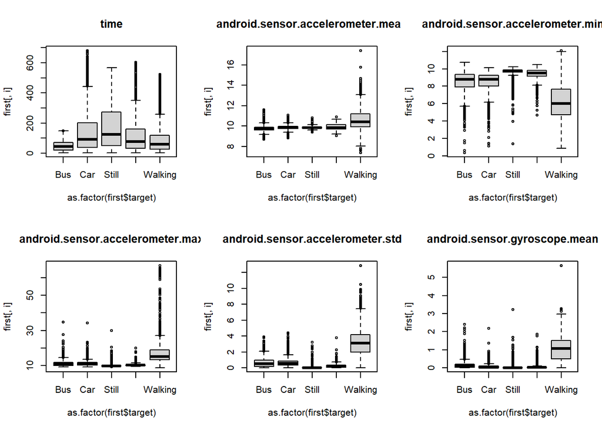

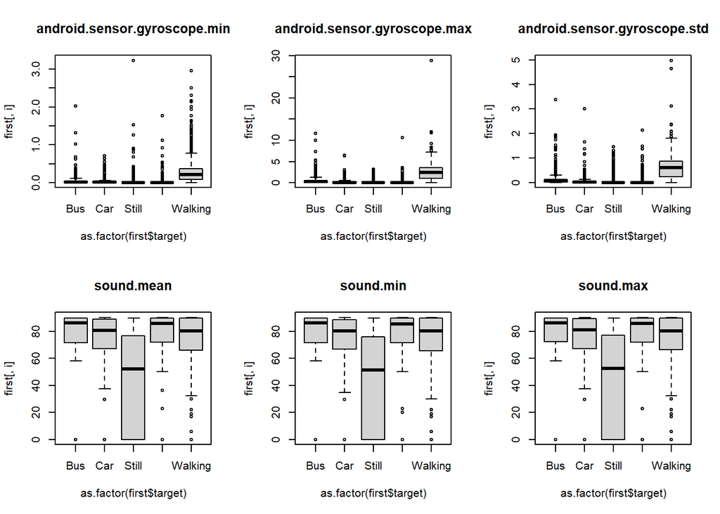

```r
# Boxplots

par(mfrow=c(2, 3))

# Dfirst data set
for (i in 1:(length(first)-1)) {
  boxplot(first[,i]~as.factor(first$target), main=names(first[i]))
}
```

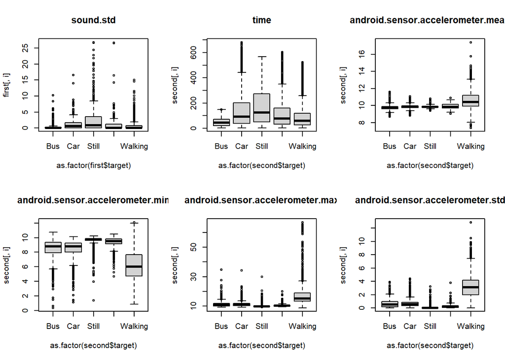

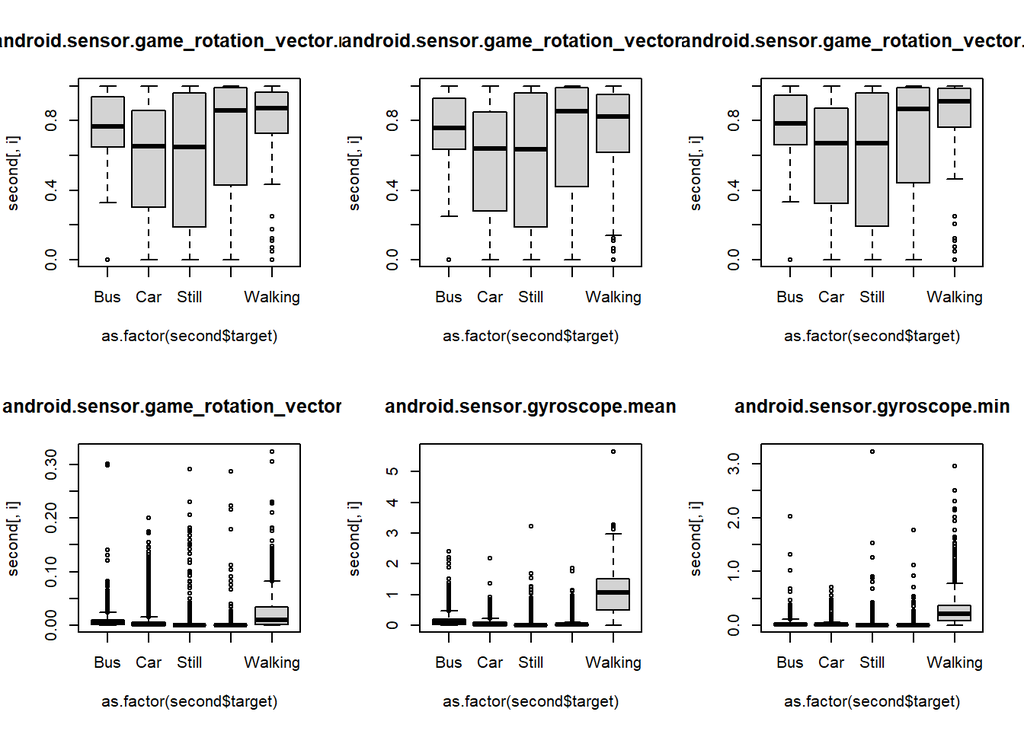

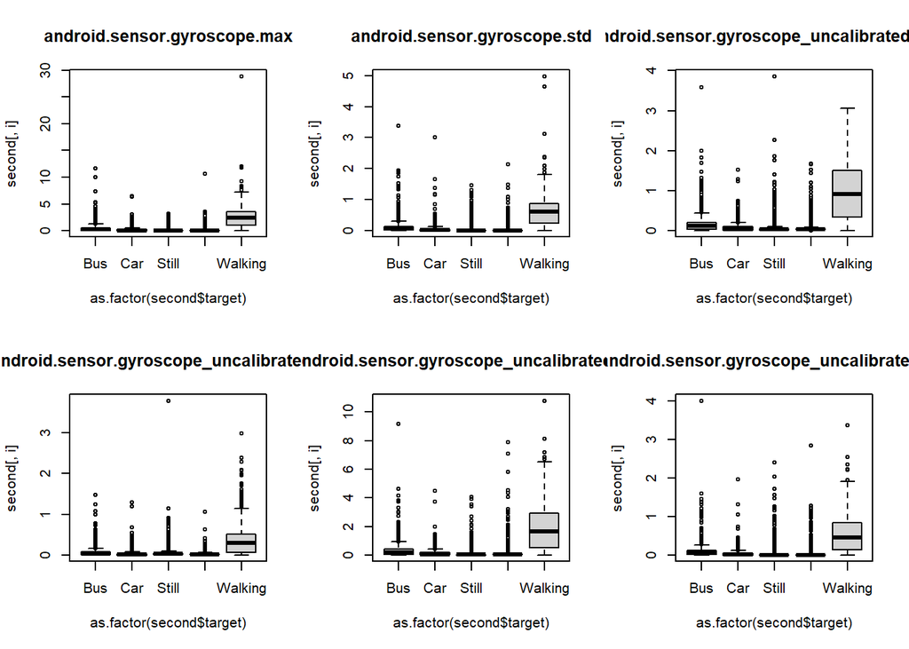

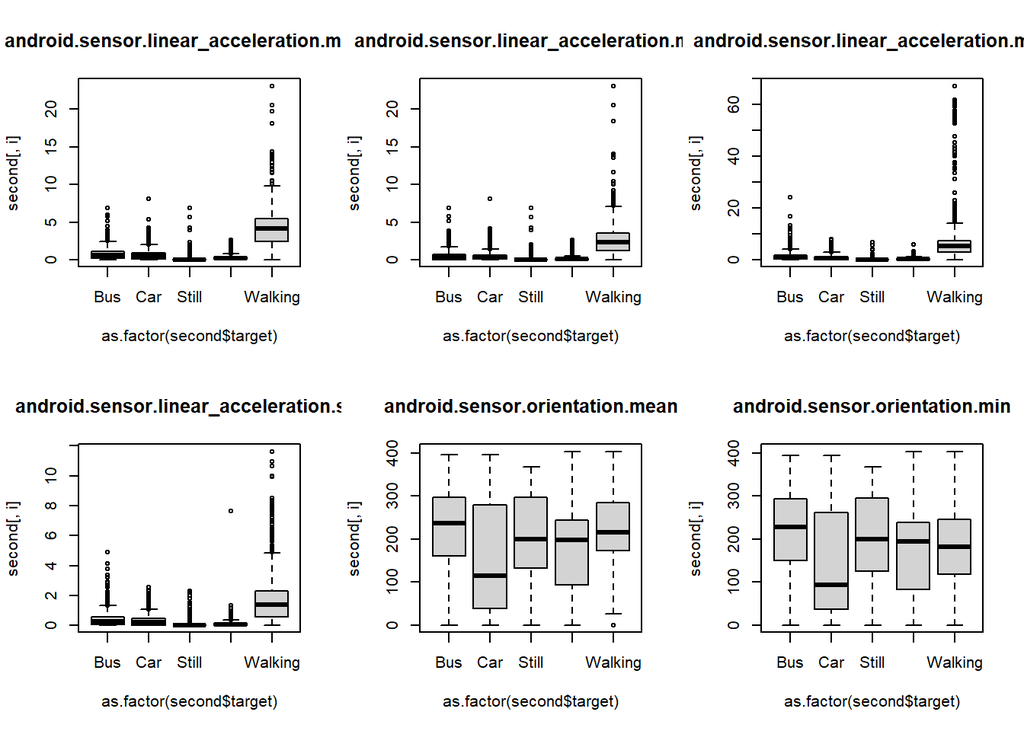

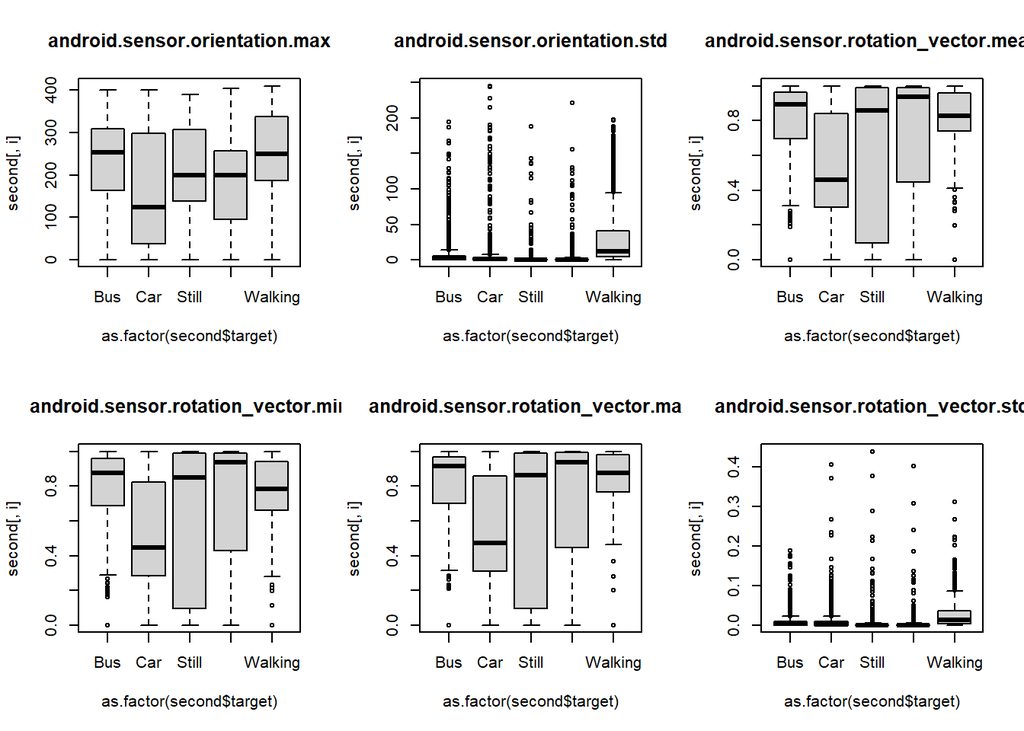

```r
# Dsecond data set
for (i in 1:(length(second)-1)) {
  boxplot(second[,i]~as.factor(second$target), main=names(second[i]))
}
```

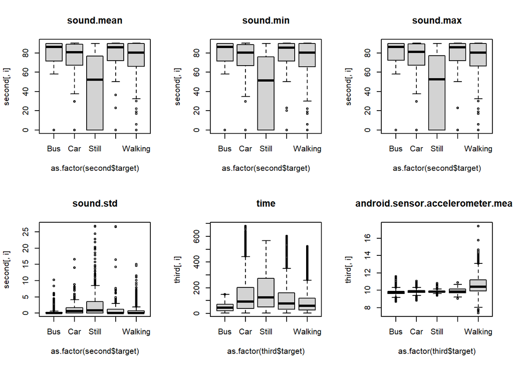

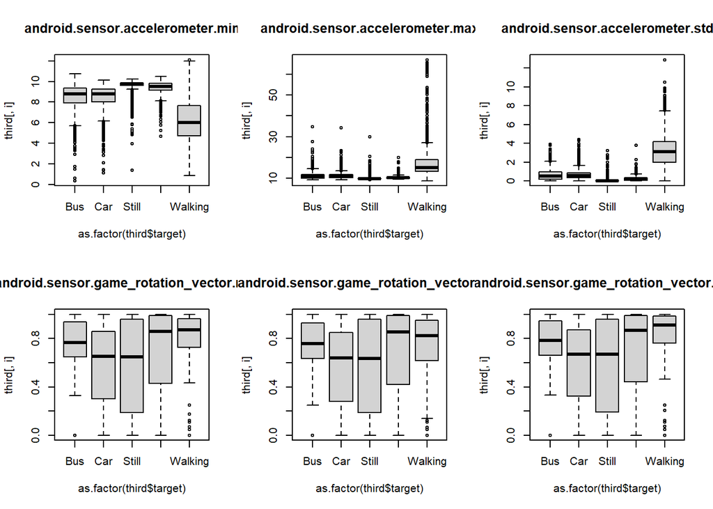

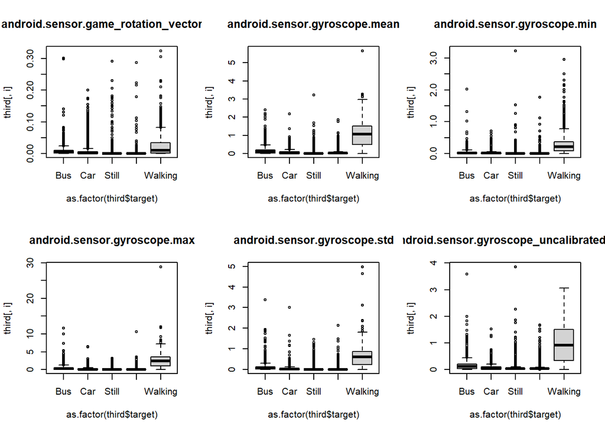

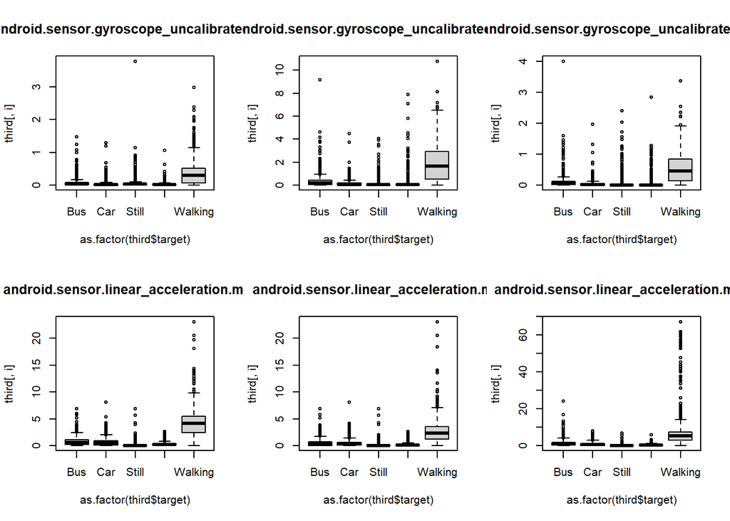

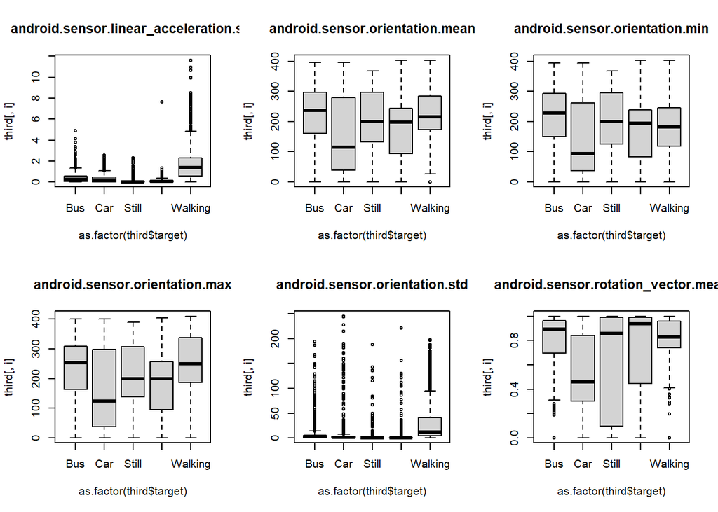

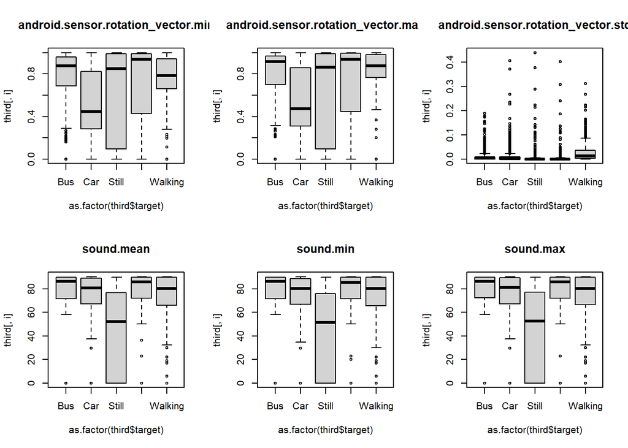

```r
# Dthird data set
for (i in 1:(length(third)-1)) {
  boxplot(third[,i]~as.factor(third$target), main=names(third[i]))
}
```

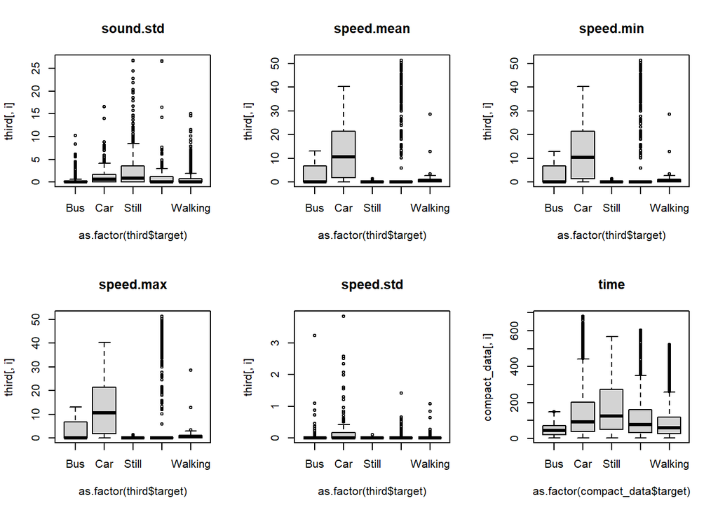

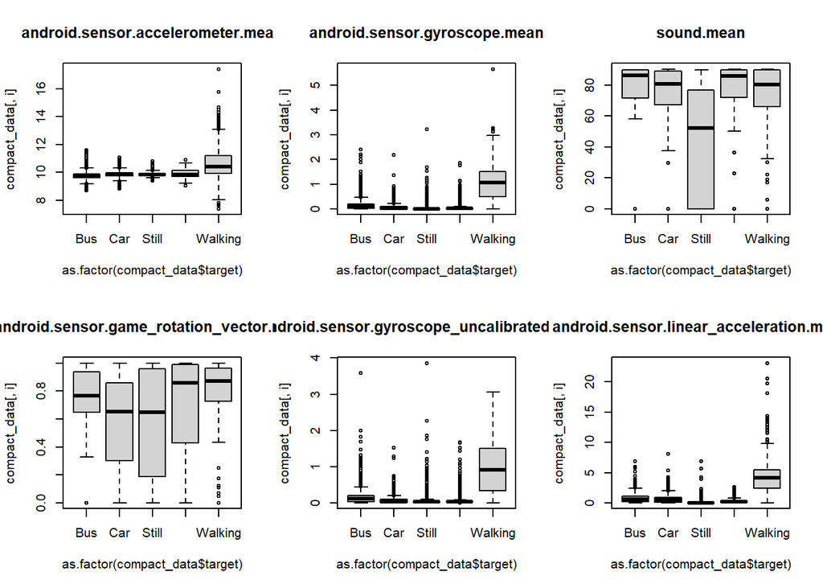

```r
# Compact data set
for (i in 1:(length(compact_data)-1)) {
  boxplot(compact_data[,i]~as.factor(compact_data$target), main=names(compact_data[i]))
}
```

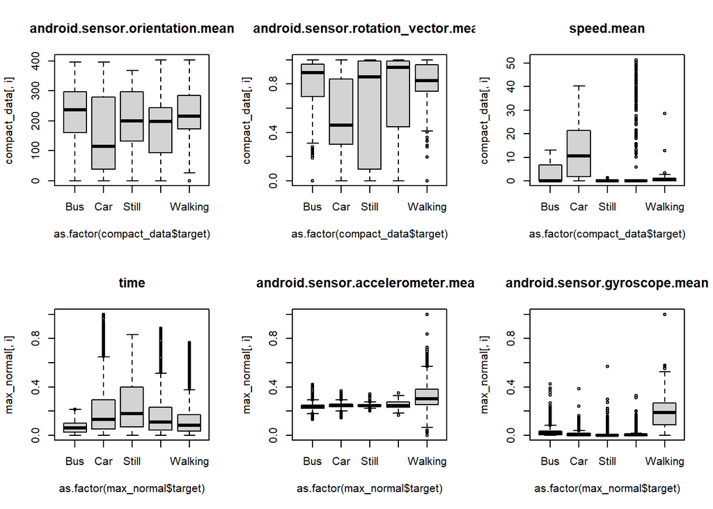

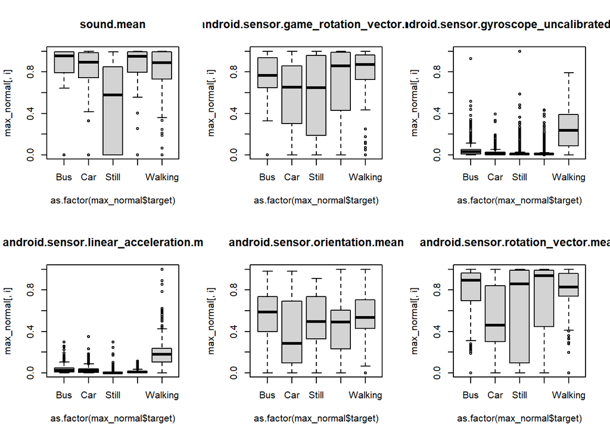

```r
# Max Normal data set
for (i in 1:(length(max_normal)-1)) {
  boxplot(max_normal[,i]~as.factor(max_normal$target), main=names(max_normal[i]))
}
```

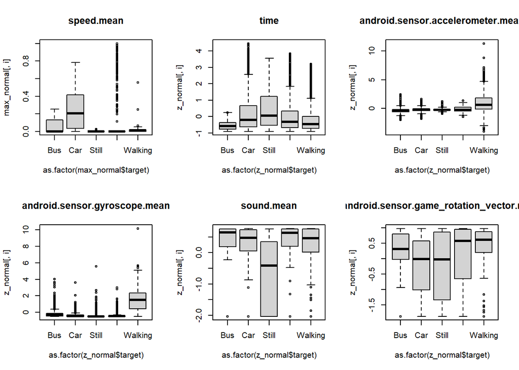

```r
# Z Normal data set
for (i in 1:(length(z_normal)-1)) {
  boxplot(z_normal[,i]~as.factor(z_normal$target), main=names(z_normal[i]))
}
```

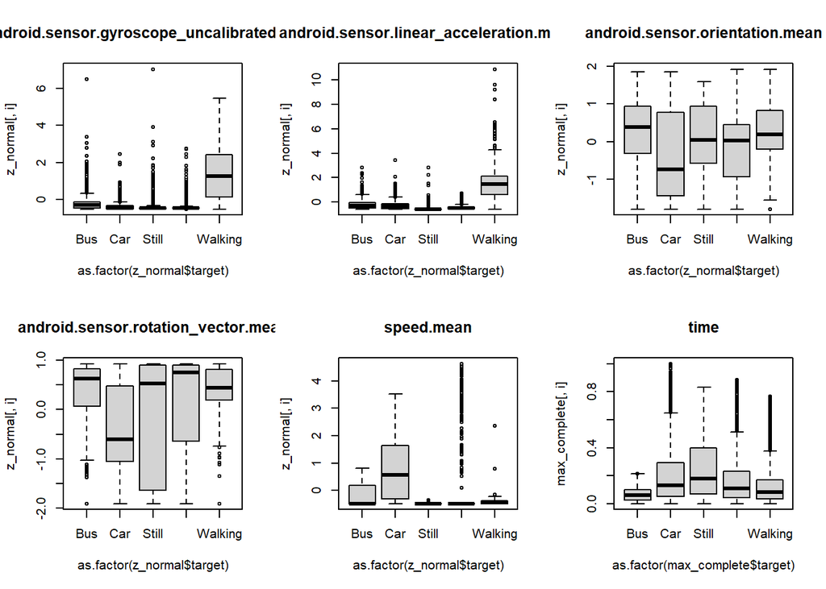

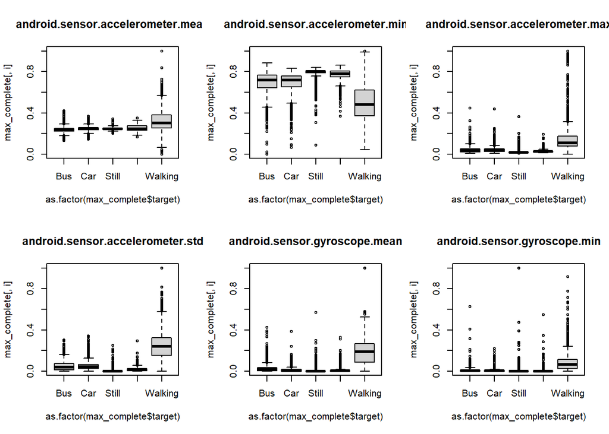

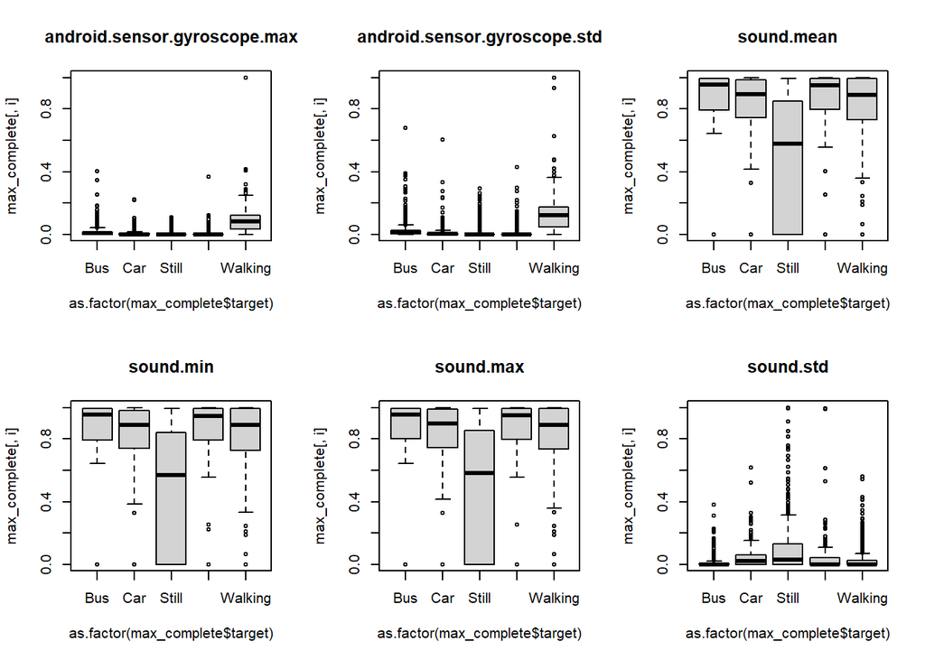

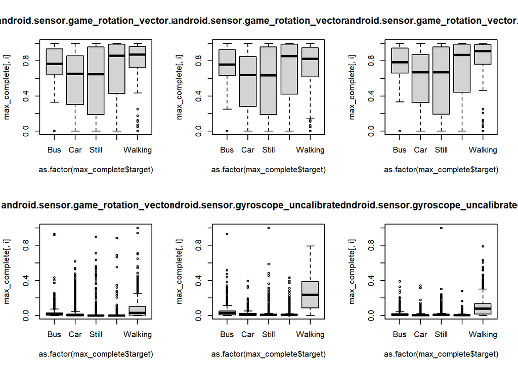

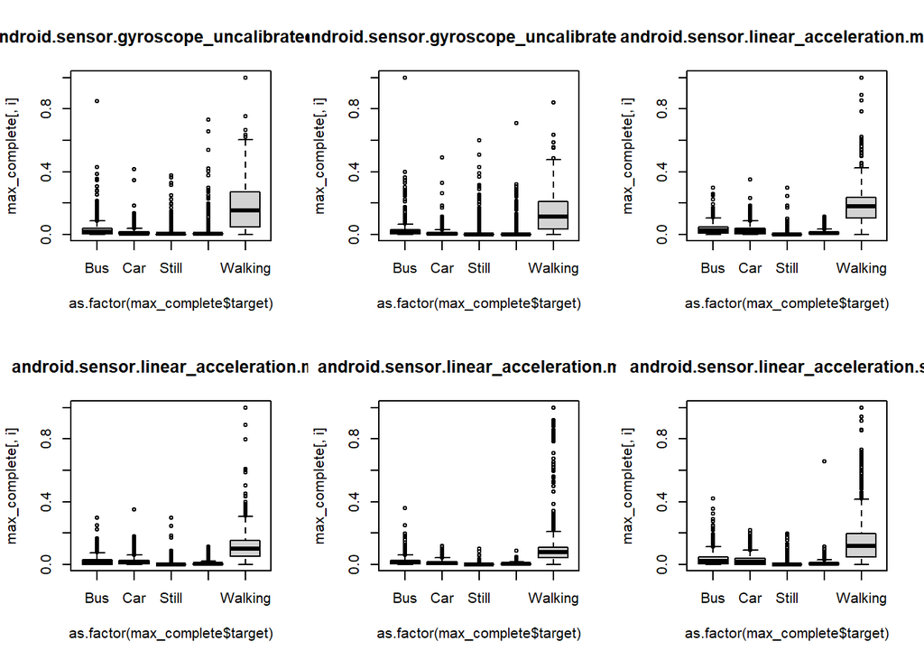

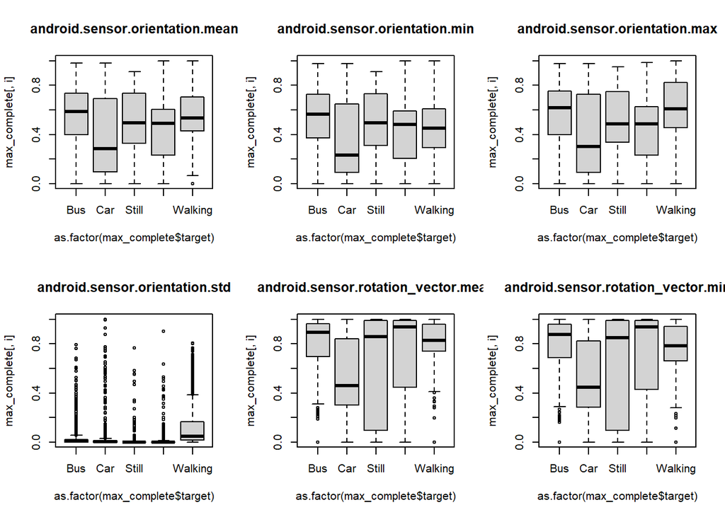

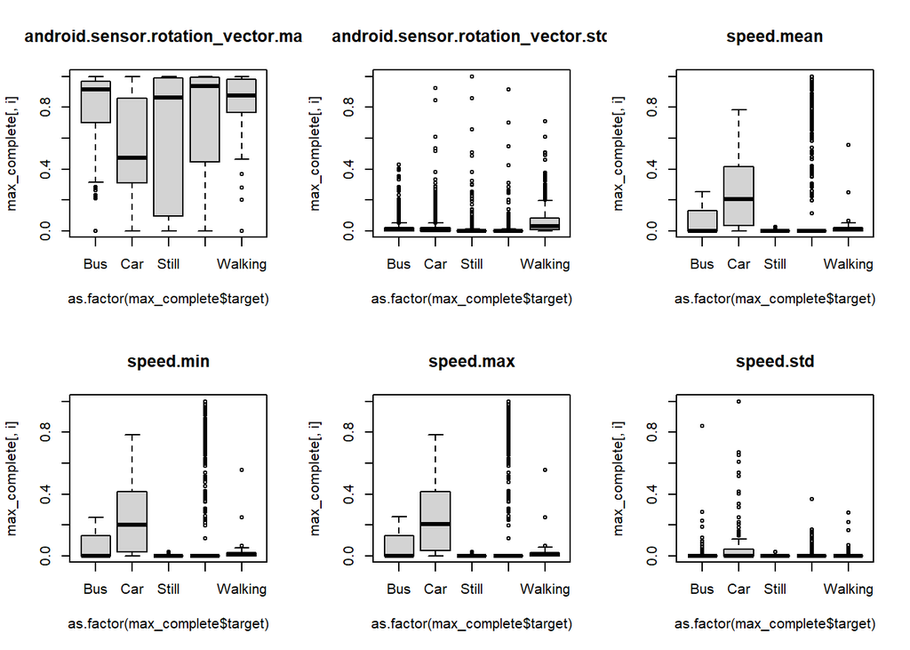

```r
# Max Normal Complete data set
for (i in 1:(length(max_complete)-1)) {
  boxplot(max_complete[,i]~as.factor(max_complete$target), main=names(max_complete[i]))
}
```

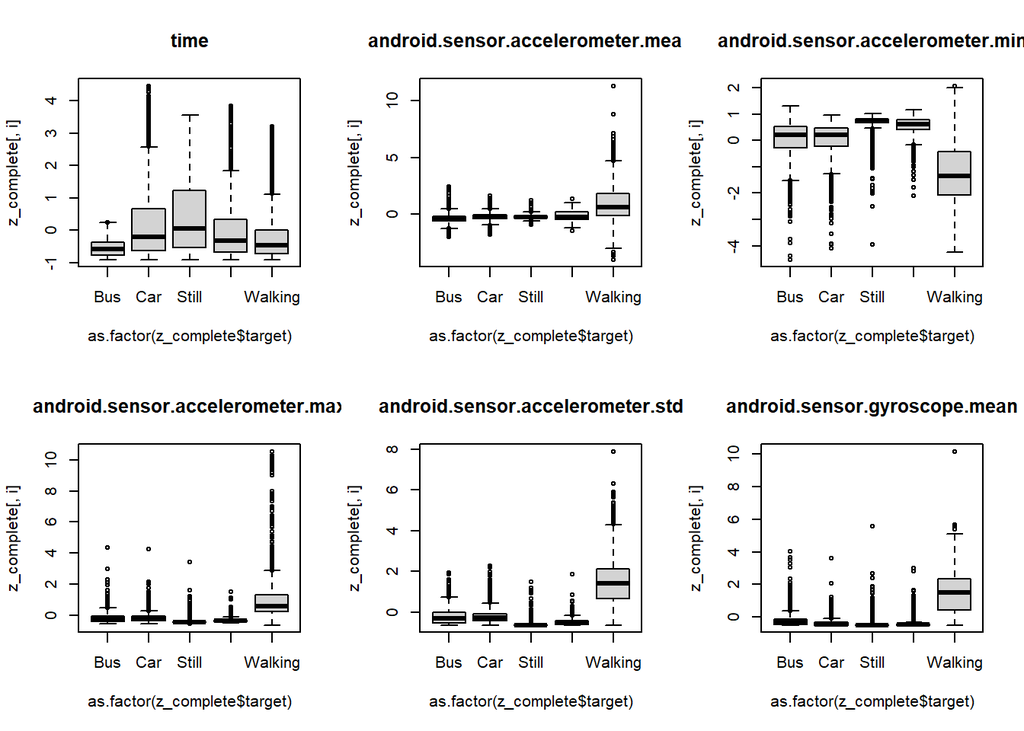

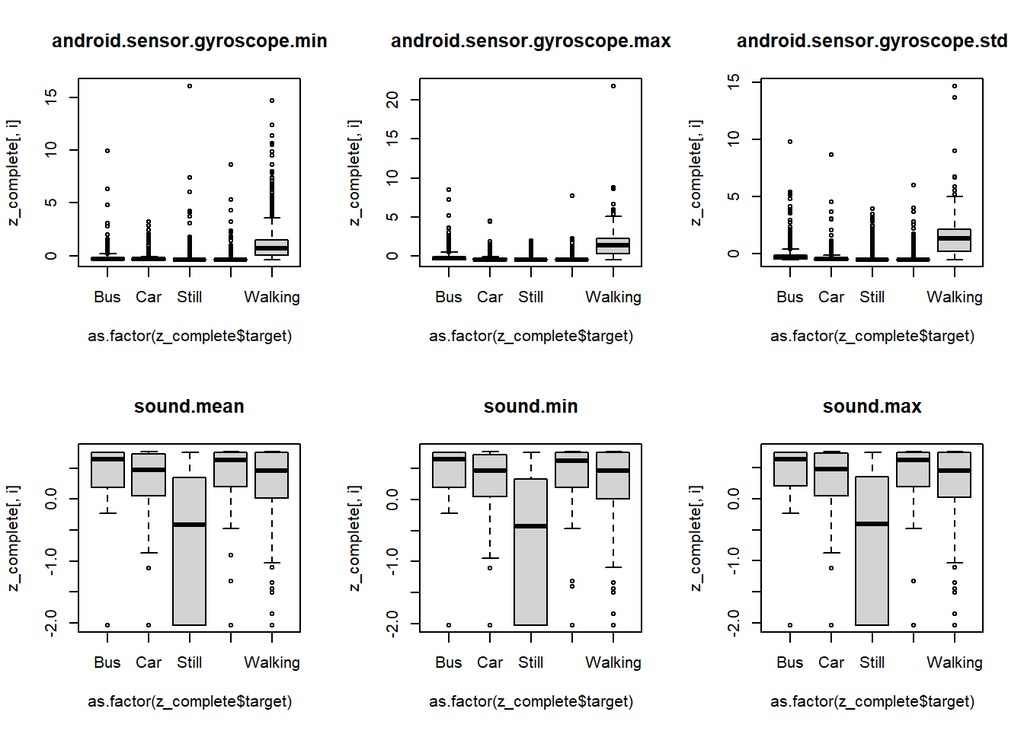

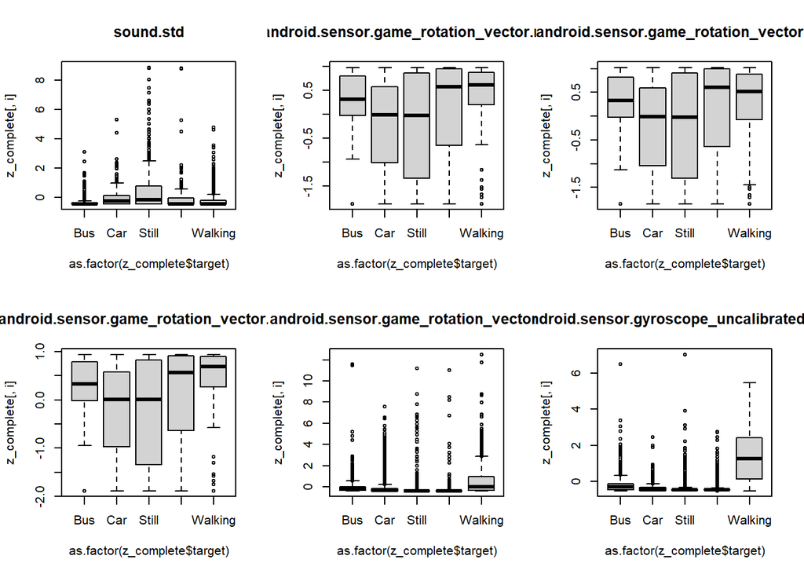

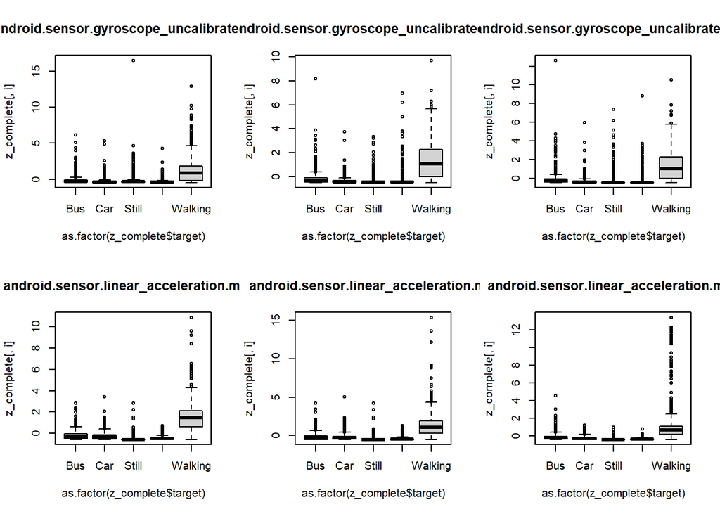

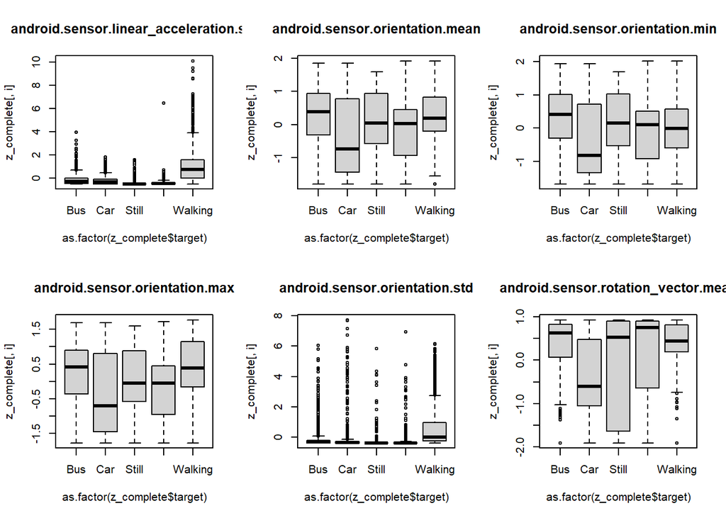

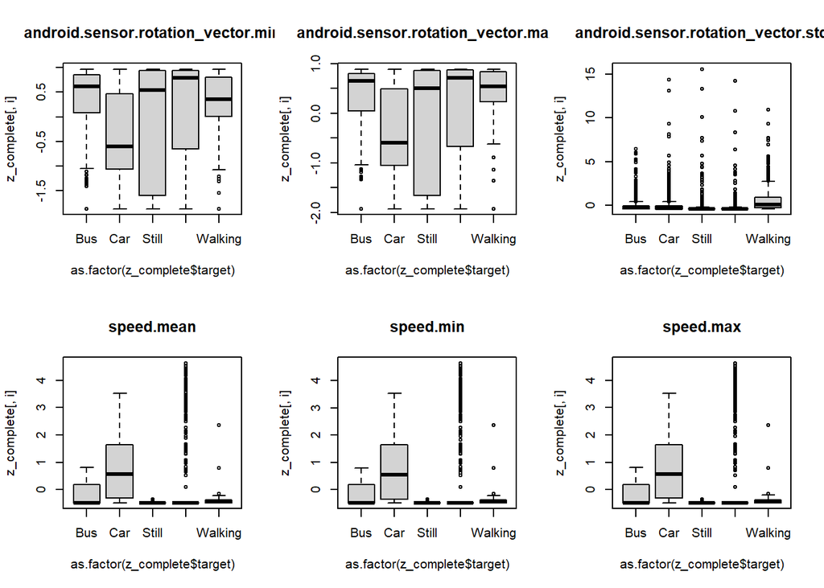

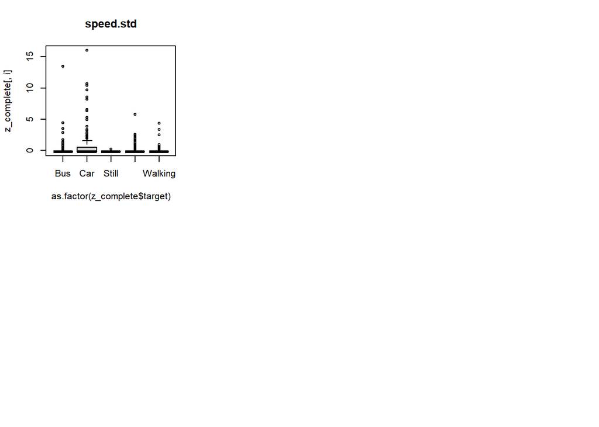

```r
# Z Normal  Complete data set
for (i in 1:(length(z_complete)-1)) {
  boxplot(z_complete[,i]~as.factor(z_complete$target), main=names(z_complete[i]))
}
```

### ANOVA testing for feature variables and responses

Analysis of variance (ANOVA) is a statistical technique that is used to check if the means of two or more groups are significantly different from each other. Three stars (or asterisks) represent a highly significant p-value. Consequently, a small p-value for the intercept and the slope indicates that we can reject the null hypothesis which allows us to conclude that there is a strong relationship between predictor and response. Typically, a p-value of 5% (.05) or less is a good cut-off point.

```r
# Dfirst data set
first$target <- factor(first$target)
formulae <- lapply(colnames(first)[2:ncol(first)-1], function(x) as.formula(paste0(x, " ~ target")))
anovafirst <- lapply(formulae, function(x) summary(aov(x, data = first)))
names(anovafirst) <- format(formulae)
anovafirst # summary of anova test for each column with target
```

```
## $`time ~ target`
##               Df   Sum Sq Mean Sq F value Pr(>F)
## target         4  9955692 2488923   173.9 <2e-16 ***
## Residuals   5888 84291036   14316
## ---
## Signif. codes:  0 '***' 0.001 '**' 0.01 '*' 0.05 '.' 0.1 ' ' 1
##
## $`android.sensor.accelerometer.mean ~ target`
##               Df Sum Sq Mean Sq F value Pr(>F)
## target         4  624.8  156.19   481.4 <2e-16 ***
## Residuals   5888 1910.4    0.32
## ---
## Signif. codes:  0 '***' 0.001 '**' 0.01 '*' 0.05 '.' 0.1 ' ' 1
##
## $`android.sensor.accelerometer.min ~ target`
##               Df Sum Sq Mean Sq F value Pr(>F)
## target         4   8626  2156.4    1256 <2e-16 ***
## Residuals   5888  10106     1.7
## ---
## Signif. codes:  0 '***' 0.001 '**' 0.01 '*' 0.05 '.' 0.1 ' ' 1
##
## $`android.sensor.accelerometer.max ~ target`
##               Df Sum Sq Mean Sq F value Pr(>F)
## target         4  48445   12111   650.9 <2e-16 ***
## Residuals   5888 109556      19
## ---
## Signif. codes:  0 '***' 0.001 '**' 0.01 '*' 0.05 '.' 0.1 ' ' 1
##
## $`android.sensor.accelerometer.std ~ target`
##               Df Sum Sq Mean Sq F value Pr(>F)
## target         4   7674    1919    1988 <2e-16 ***
## Residuals   5888   5682       1
## ---
## Signif. codes:  0 '***' 0.001 '**' 0.01 '*' 0.05 '.' 0.1 ' ' 1
##
## $`android.sensor.gyroscope.mean ~ target`
##               Df Sum Sq Mean Sq F value Pr(>F)
## target         4  854.2  213.54    1575 <2e-16 ***
## Residuals   5888  798.3    0.14
## ---
```

[output cut: 35 more lines]

```
## Signif. codes:  0 '***' 0.001 '**' 0.01 '*' 0.05 '.' 0.1 ' ' 1
##
## $`sound.max ~ target`
##               Df  Sum Sq Mean Sq F value Pr(>F)
## target         4  535649  133912   141.7 <2e-16 ***
## Residuals   5888 5566108     945
## ---
## Signif. codes:  0 '***' 0.001 '**' 0.01 '*' 0.05 '.' 0.1 ' ' 1
##
## $`sound.std ~ target`
##               Df Sum Sq Mean Sq F value Pr(>F)
## target         4   2593   648.4   83.01 <2e-16 ***
## Residuals   5888  45987     7.8
## ---
## Signif. codes:  0 '***' 0.001 '**' 0.01 '*' 0.05 '.' 0.1 ' ' 1
```

```r
pfirst <- unlist(lapply(anovafirst, function(x) x[[1]]$"Pr(>F)"[1]))
pvaluesfirst <- data.frame(Sensor = sub(' ~ target', '', names(pfirst)), pvalue = pfirst)
pvaluesfirst # p-values from anova test in data frame
```

```
##                                                                       Sensor
## time ~ target                                                           time
## android.sensor.accelerometer.mean ~ target android.sensor.accelerometer.mean
## android.sensor.accelerometer.min ~ target   android.sensor.accelerometer.min
## android.sensor.accelerometer.max ~ target   android.sensor.accelerometer.max
## android.sensor.accelerometer.std ~ target   android.sensor.accelerometer.std
## android.sensor.gyroscope.mean ~ target         android.sensor.gyroscope.mean
## android.sensor.gyroscope.min ~ target           android.sensor.gyroscope.min
## android.sensor.gyroscope.max ~ target           android.sensor.gyroscope.max
## android.sensor.gyroscope.std ~ target           android.sensor.gyroscope.std
## sound.mean ~ target                                               sound.mean
## sound.min ~ target                                                 sound.min
## sound.max ~ target                                                 sound.max
## sound.std ~ target                                                 sound.std
##                                                   pvalue
## time ~ target                              5.683505e-141
## android.sensor.accelerometer.mean ~ target  0.000000e+00
## android.sensor.accelerometer.min ~ target   0.000000e+00
## android.sensor.accelerometer.max ~ target   0.000000e+00
## android.sensor.accelerometer.std ~ target   0.000000e+00
## android.sensor.gyroscope.mean ~ target      0.000000e+00
## android.sensor.gyroscope.min ~ target       0.000000e+00
## android.sensor.gyroscope.max ~ target       0.000000e+00
## android.sensor.gyroscope.std ~ target       0.000000e+00
## sound.mean ~ target                        2.214771e-119
## sound.min ~ target                         8.258903e-123
## sound.max ~ target                         8.683652e-116
## sound.std ~ target                          1.133688e-68
```

The features android.sensor.accelerometer.mean, android.sensor.accelerometer.min, android.sensor.accelerometer.max, android.sensor.accelerometer.std, android.sensor.gyroscope.mean, android.sensor.gyroscope.min, android.sensor.gyroscope.max, and android.sensor.gyroscope.std all have very small p-values .

```r
# Dsecond data set
second$target <- factor(second$target)
formulae <- lapply(colnames(second)[2:ncol(second)-1], function(x) as.formula(paste0(x, " ~ target")))
anovasecond <- lapply(formulae, function(x) summary(aov(x, data = second)))
names(anovasecond) <- format(formulae)
anovasecond # summary of anova test for each column with target
```

```
## $`time ~ target`
##               Df   Sum Sq Mean Sq F value Pr(>F)
## target         4  9955692 2488923   173.9 <2e-16 ***
## Residuals   5888 84291036   14316
## ---
## Signif. codes:  0 '***' 0.001 '**' 0.01 '*' 0.05 '.' 0.1 ' ' 1
##
## $`android.sensor.accelerometer.mean ~ target`
##               Df Sum Sq Mean Sq F value Pr(>F)
## target         4  624.8  156.19   481.4 <2e-16 ***
## Residuals   5888 1910.4    0.32
## ---
## Signif. codes:  0 '***' 0.001 '**' 0.01 '*' 0.05 '.' 0.1 ' ' 1
##
## $`android.sensor.accelerometer.min ~ target`
##               Df Sum Sq Mean Sq F value Pr(>F)
## target         4   8626  2156.4    1256 <2e-16 ***
## Residuals   5888  10106     1.7
## ---
## Signif. codes:  0 '***' 0.001 '**' 0.01 '*' 0.05 '.' 0.1 ' ' 1
##
## $`android.sensor.accelerometer.max ~ target`
##               Df Sum Sq Mean Sq F value Pr(>F)
## target         4  48445   12111   650.9 <2e-16 ***
## Residuals   5888 109556      19
## ---
## Signif. codes:  0 '***' 0.001 '**' 0.01 '*' 0.05 '.' 0.1 ' ' 1
##
## $`android.sensor.accelerometer.std ~ target`
##               Df Sum Sq Mean Sq F value Pr(>F)
## target         4   7674    1919    1988 <2e-16 ***
## Residuals   5888   5682       1
## ---
## Signif. codes:  0 '***' 0.001 '**' 0.01 '*' 0.05 '.' 0.1 ' ' 1
##
## $`android.sensor.game_rotation_vector.mean ~ target`
##               Df Sum Sq Mean Sq F value Pr(>F)
## target         4   31.0   7.751   66.29 <2e-16 ***
## Residuals   5888  688.5   0.117
## ---
```

[output cut: 175 more lines]

```
## Signif. codes:  0 '***' 0.001 '**' 0.01 '*' 0.05 '.' 0.1 ' ' 1
##
## $`sound.max ~ target`
##               Df  Sum Sq Mean Sq F value Pr(>F)
## target         4  535649  133912   141.7 <2e-16 ***
## Residuals   5888 5566108     945
## ---
## Signif. codes:  0 '***' 0.001 '**' 0.01 '*' 0.05 '.' 0.1 ' ' 1
##
## $`sound.std ~ target`
##               Df Sum Sq Mean Sq F value Pr(>F)
## target         4   2593   648.4   83.01 <2e-16 ***
## Residuals   5888  45987     7.8
## ---
## Signif. codes:  0 '***' 0.001 '**' 0.01 '*' 0.05 '.' 0.1 ' ' 1
```

```r
psecond <- unlist(lapply(anovasecond, function(x) x[[1]]$"Pr(>F)"[1]))
pvaluessecond <- data.frame(Sensor = sub(' ~ target', '', names(psecond)), pvalue = psecond)
pvaluessecond # p-values from anova test in data frame
```

```
##                                                                                         Sensor
## time ~ target                                                                             time
## android.sensor.accelerometer.mean ~ target                   android.sensor.accelerometer.mean
## android.sensor.accelerometer.min ~ target                     android.sensor.accelerometer.min
## android.sensor.accelerometer.max ~ target                     android.sensor.accelerometer.max
## android.sensor.accelerometer.std ~ target                     android.sensor.accelerometer.std
## android.sensor.game_rotation_vector.mean ~ target     android.sensor.game_rotation_vector.mean
## android.sensor.game_rotation_vector.min ~ target       android.sensor.game_rotation_vector.min
## android.sensor.game_rotation_vector.max ~ target       android.sensor.game_rotation_vector.max
## android.sensor.game_rotation_vector.std ~ target       android.sensor.game_rotation_vector.std
## android.sensor.gyroscope.mean ~ target                           android.sensor.gyroscope.mean
## android.sensor.gyroscope.min ~ target                             android.sensor.gyroscope.min
## android.sensor.gyroscope.max ~ target                             android.sensor.gyroscope.max
## android.sensor.gyroscope.std ~ target                             android.sensor.gyroscope.std
## android.sensor.gyroscope_uncalibrated.mean ~ target android.sensor.gyroscope_uncalibrated.mean
## android.sensor.gyroscope_uncalibrated.min ~ target   android.sensor.gyroscope_uncalibrated.min
## android.sensor.gyroscope_uncalibrated.max ~ target   android.sensor.gyroscope_uncalibrated.max
## android.sensor.gyroscope_uncalibrated.std ~ target   android.sensor.gyroscope_uncalibrated.std
## android.sensor.linear_acceleration.mean ~ target       android.sensor.linear_acceleration.mean
## android.sensor.linear_acceleration.min ~ target         android.sensor.linear_acceleration.min
## android.sensor.linear_acceleration.max ~ target         android.sensor.linear_acceleration.max
## android.sensor.linear_acceleration.std ~ target         android.sensor.linear_acceleration.std
## android.sensor.orientation.mean ~ target                       android.sensor.orientation.mean
## android.sensor.orientation.min ~ target                         android.sensor.orientation.min
## android.sensor.orientation.max ~ target                         android.sensor.orientation.max
## android.sensor.orientation.std ~ target                         android.sensor.orientation.std
## android.sensor.rotation_vector.mean ~ target               android.sensor.rotation_vector.mean
## android.sensor.rotation_vector.min ~ target                 android.sensor.rotation_vector.min
## android.sensor.rotation_vector.max ~ target                 android.sensor.rotation_vector.max
## android.sensor.rotation_vector.std ~ target                 android.sensor.rotation_vector.std
## sound.mean ~ target                                                                 sound.mean
## sound.min ~ target                                                                   sound.min
## sound.max ~ target                                                                   sound.max
## sound.std ~ target                                                                   sound.std
##                                                            pvalue
## time ~ target                                       5.683505e-141
## android.sensor.accelerometer.mean ~ target           0.000000e+00
## android.sensor.accelerometer.min ~ target            0.000000e+00
## android.sensor.accelerometer.max ~ target            0.000000e+00
## android.sensor.accelerometer.std ~ target            0.000000e+00
```

[output cut: 13 more lines]

```
## android.sensor.linear_acceleration.min ~ target      0.000000e+00
## android.sensor.linear_acceleration.max ~ target      0.000000e+00
## android.sensor.linear_acceleration.std ~ target      0.000000e+00
## android.sensor.orientation.mean ~ target             3.801032e-90
## android.sensor.orientation.min ~ target              1.424326e-69
## android.sensor.orientation.max ~ target             1.520416e-120
## android.sensor.orientation.std ~ target             8.795647e-216
## android.sensor.rotation_vector.mean ~ target        3.856609e-111
## android.sensor.rotation_vector.min ~ target         3.608014e-105
## android.sensor.rotation_vector.max ~ target         3.108497e-115
## android.sensor.rotation_vector.std ~ target         9.738874e-112
## sound.mean ~ target                                 2.214771e-119
## sound.min ~ target                                  8.258903e-123
## sound.max ~ target                                  8.683652e-116
## sound.std ~ target                                   1.133688e-68
```

The features android.sensor.accelerometer.mean, android.sensor.accelerometer.min, android.sensor.accelerometer.max,android.sensor.accelerometer.std, android.sensor.gyroscope.mean,android.sensor.gyroscope.min,android.sensor.gyroscope.max,android.sensor.gyroscope.std, android.sensor.gyroscope_uncalibrated.mean,android.sensor.gyroscope_uncalibrated.min, android.sensor.gyroscope_uncalibrated.max,android.sensor.gyroscope_uncalibrated.std,ndroid.sensor.linear_acceleration.mean, android.sensor.linear_acceleration.min, android.sensor.linear_acceleration.max, and android.sensor.linear_acceleration.std all have very small p-vlaues

```r
# Dthird data set
third$target <- factor(third$target)
formulae <- lapply(colnames(third)[2:ncol(third)-1], function(x) as.formula(paste0(x, " ~ target")))
anovathird <- lapply(formulae, function(x) summary(aov(x, data = third)))
names(anovathird) <- format(formulae)
anovathird # summary of anova test for each column with target
```

```
## $`time ~ target`
##               Df   Sum Sq Mean Sq F value Pr(>F)
## target         4  9955692 2488923   173.9 <2e-16 ***
## Residuals   5888 84291036   14316
## ---
## Signif. codes:  0 '***' 0.001 '**' 0.01 '*' 0.05 '.' 0.1 ' ' 1
##
## $`android.sensor.accelerometer.mean ~ target`
##               Df Sum Sq Mean Sq F value Pr(>F)
## target         4  624.8  156.19   481.4 <2e-16 ***
## Residuals   5888 1910.4    0.32
## ---
## Signif. codes:  0 '***' 0.001 '**' 0.01 '*' 0.05 '.' 0.1 ' ' 1
##
## $`android.sensor.accelerometer.min ~ target`
##               Df Sum Sq Mean Sq F value Pr(>F)
## target         4   8626  2156.4    1256 <2e-16 ***
## Residuals   5888  10106     1.7
## ---
## Signif. codes:  0 '***' 0.001 '**' 0.01 '*' 0.05 '.' 0.1 ' ' 1
##
## $`android.sensor.accelerometer.max ~ target`
##               Df Sum Sq Mean Sq F value Pr(>F)
## target         4  48445   12111   650.9 <2e-16 ***
## Residuals   5888 109556      19
## ---
## Signif. codes:  0 '***' 0.001 '**' 0.01 '*' 0.05 '.' 0.1 ' ' 1
##
## $`android.sensor.accelerometer.std ~ target`
##               Df Sum Sq Mean Sq F value Pr(>F)
## target         4   7674    1919    1988 <2e-16 ***
## Residuals   5888   5682       1
## ---
## Signif. codes:  0 '***' 0.001 '**' 0.01 '*' 0.05 '.' 0.1 ' ' 1
##
## $`android.sensor.game_rotation_vector.mean ~ target`
##               Df Sum Sq Mean Sq F value Pr(>F)
## target         4   31.0   7.751   66.29 <2e-16 ***
## Residuals   5888  688.5   0.117
## ---
```

[output cut: 203 more lines]

```
## Signif. codes:  0 '***' 0.001 '**' 0.01 '*' 0.05 '.' 0.1 ' ' 1
##
## $`speed.max ~ target`
##               Df Sum Sq Mean Sq F value Pr(>F)
## target         4 135426   33857   435.7 <2e-16 ***
## Residuals   5888 457545      78
## ---
## Signif. codes:  0 '***' 0.001 '**' 0.01 '*' 0.05 '.' 0.1 ' ' 1
##
## $`speed.std ~ target`
##               Df Sum Sq Mean Sq F value Pr(>F)
## target         4  29.51   7.379   145.6 <2e-16 ***
## Residuals   5888 298.44   0.051
## ---
## Signif. codes:  0 '***' 0.001 '**' 0.01 '*' 0.05 '.' 0.1 ' ' 1
```

```r
pthird <- unlist(lapply(anovathird, function(x) x[[1]]$"Pr(>F)"[1]))
pvaluesthird <- data.frame(Sensor = sub(' ~ target', '', names(pthird)), pvalue = pthird)
pvaluesthird # p-values from anova test in data frame
```

```
##                                                                                         Sensor
## time ~ target                                                                             time
## android.sensor.accelerometer.mean ~ target                   android.sensor.accelerometer.mean
## android.sensor.accelerometer.min ~ target                     android.sensor.accelerometer.min
## android.sensor.accelerometer.max ~ target                     android.sensor.accelerometer.max
## android.sensor.accelerometer.std ~ target                     android.sensor.accelerometer.std
## android.sensor.game_rotation_vector.mean ~ target     android.sensor.game_rotation_vector.mean
## android.sensor.game_rotation_vector.min ~ target       android.sensor.game_rotation_vector.min
## android.sensor.game_rotation_vector.max ~ target       android.sensor.game_rotation_vector.max
## android.sensor.game_rotation_vector.std ~ target       android.sensor.game_rotation_vector.std
## android.sensor.gyroscope.mean ~ target                           android.sensor.gyroscope.mean
## android.sensor.gyroscope.min ~ target                             android.sensor.gyroscope.min
## android.sensor.gyroscope.max ~ target                             android.sensor.gyroscope.max
## android.sensor.gyroscope.std ~ target                             android.sensor.gyroscope.std
## android.sensor.gyroscope_uncalibrated.mean ~ target android.sensor.gyroscope_uncalibrated.mean
## android.sensor.gyroscope_uncalibrated.min ~ target   android.sensor.gyroscope_uncalibrated.min
## android.sensor.gyroscope_uncalibrated.max ~ target   android.sensor.gyroscope_uncalibrated.max
## android.sensor.gyroscope_uncalibrated.std ~ target   android.sensor.gyroscope_uncalibrated.std
## android.sensor.linear_acceleration.mean ~ target       android.sensor.linear_acceleration.mean
## android.sensor.linear_acceleration.min ~ target         android.sensor.linear_acceleration.min
## android.sensor.linear_acceleration.max ~ target         android.sensor.linear_acceleration.max
## android.sensor.linear_acceleration.std ~ target         android.sensor.linear_acceleration.std
## android.sensor.orientation.mean ~ target                       android.sensor.orientation.mean
## android.sensor.orientation.min ~ target                         android.sensor.orientation.min
## android.sensor.orientation.max ~ target                         android.sensor.orientation.max
## android.sensor.orientation.std ~ target                         android.sensor.orientation.std
## android.sensor.rotation_vector.mean ~ target               android.sensor.rotation_vector.mean
## android.sensor.rotation_vector.min ~ target                 android.sensor.rotation_vector.min
## android.sensor.rotation_vector.max ~ target                 android.sensor.rotation_vector.max
## android.sensor.rotation_vector.std ~ target                 android.sensor.rotation_vector.std
## sound.mean ~ target                                                                 sound.mean
## sound.min ~ target                                                                   sound.min
## sound.max ~ target                                                                   sound.max
## sound.std ~ target                                                                   sound.std
## speed.mean ~ target                                                                 speed.mean
## speed.min ~ target                                                                   speed.min
## speed.max ~ target                                                                   speed.max
## speed.std ~ target                                                                   speed.std
##                                                            pvalue
## time ~ target                                       5.683505e-141
```

[output cut: 21 more lines]

```
## android.sensor.orientation.min ~ target              1.424326e-69
## android.sensor.orientation.max ~ target             1.520416e-120
## android.sensor.orientation.std ~ target             8.795647e-216
## android.sensor.rotation_vector.mean ~ target        3.856609e-111
## android.sensor.rotation_vector.min ~ target         3.608014e-105
## android.sensor.rotation_vector.max ~ target         3.108497e-115
## android.sensor.rotation_vector.std ~ target         9.738874e-112
## sound.mean ~ target                                 2.214771e-119
## sound.min ~ target                                  8.258903e-123
## sound.max ~ target                                  8.683652e-116
## sound.std ~ target                                   1.133688e-68
## speed.mean ~ target                                  0.000000e+00
## speed.min ~ target                                   0.000000e+00
## speed.max ~ target                                   0.000000e+00
## speed.std ~ target                                  7.077510e-119
```

The features android.sensor.accelerometer.mean, android.sensor.accelerometer.min, android.sensor.accelerometer.max, android.sensor.accelerometer.std, android.sensor.gyroscope.mean, android.sensor.gyroscope.min, android.sensor.gyroscope.max, android.sensor.gyroscope.std, android.sensor.gyroscope_uncalibrated.mean, android.sensor.gyroscope_uncalibrated.min, android.sensor.gyroscope_uncalibrated.max, android.sensor.gyroscope_uncalibrated.std, android.sensor.linear_acceleration.mean, android.sensor.linear_acceleration.min, android.sensor.linear_acceleration.max, android.sensor.linear_acceleration.std, speed.mean+speed.min, and speed.max all have very small p-vlaues

```r
# Compact data set
compact_data$target <- factor(compact_data$target)
formulae <- lapply(colnames(compact_data)[2:ncol(compact_data)-1], function(x) as.formula(paste0(x, " ~ target")))
anovacompact_data <- lapply(formulae, function(x) summary(aov(x, data = compact_data)))
names(anovacompact_data) <- format(formulae)
anovacompact_data # summary of anova test for each column with target
```

```
## $`time ~ target`
##               Df   Sum Sq Mean Sq F value Pr(>F)
## target         4  9955692 2488923   173.9 <2e-16 ***
## Residuals   5888 84291036   14316
## ---
## Signif. codes:  0 '***' 0.001 '**' 0.01 '*' 0.05 '.' 0.1 ' ' 1
##
## $`android.sensor.accelerometer.mean ~ target`
##               Df Sum Sq Mean Sq F value Pr(>F)
## target         4  624.8  156.19   481.4 <2e-16 ***
## Residuals   5888 1910.4    0.32
## ---
## Signif. codes:  0 '***' 0.001 '**' 0.01 '*' 0.05 '.' 0.1 ' ' 1
##
## $`android.sensor.gyroscope.mean ~ target`
##               Df Sum Sq Mean Sq F value Pr(>F)
## target         4  854.2  213.54    1575 <2e-16 ***
## Residuals   5888  798.3    0.14
## ---
## Signif. codes:  0 '***' 0.001 '**' 0.01 '*' 0.05 '.' 0.1 ' ' 1
##
## $`sound.mean ~ target`
##               Df  Sum Sq Mean Sq F value Pr(>F)
## target         4  549794  137448   146.2 <2e-16 ***
## Residuals   5888 5535017     940
## ---
## Signif. codes:  0 '***' 0.001 '**' 0.01 '*' 0.05 '.' 0.1 ' ' 1
##
## $`android.sensor.game_rotation_vector.mean ~ target`
##               Df Sum Sq Mean Sq F value Pr(>F)
## target         4   31.0   7.751   66.29 <2e-16 ***
## Residuals   5888  688.5   0.117
## ---
## Signif. codes:  0 '***' 0.001 '**' 0.01 '*' 0.05 '.' 0.1 ' ' 1
##
## $`android.sensor.gyroscope_uncalibrated.mean ~ target`
##               Df Sum Sq Mean Sq F value Pr(>F)
## target         4  722.8  180.69    1300 <2e-16 ***
## Residuals   5888  818.5    0.14
## ---
```

[output cut: 14 more lines]

```
## Signif. codes:  0 '***' 0.001 '**' 0.01 '*' 0.05 '.' 0.1 ' ' 1
##
## $`android.sensor.rotation_vector.mean ~ target`
##               Df Sum Sq Mean Sq F value Pr(>F)
## target         4   61.6  15.412   135.8 <2e-16 ***
## Residuals   5888  668.3   0.114
## ---
## Signif. codes:  0 '***' 0.001 '**' 0.01 '*' 0.05 '.' 0.1 ' ' 1
##
## $`speed.mean ~ target`
##               Df Sum Sq Mean Sq F value Pr(>F)
## target         4 135060   33765   435.1 <2e-16 ***
## Residuals   5888 456945      78
## ---
## Signif. codes:  0 '***' 0.001 '**' 0.01 '*' 0.05 '.' 0.1 ' ' 1
```

```r
pcompact_data <- unlist(lapply(anovacompact_data, function(x) x[[1]]$"Pr(>F)"[1]))
pvaluescompact_data <- data.frame(Sensor = sub(' ~ target', '', names(pcompact_data)), pvalue = pcompact_data)
pvaluescompact_data # p-values from anova test in data frame
```

```
##                                                                                         Sensor
## time ~ target                                                                             time
## android.sensor.accelerometer.mean ~ target                   android.sensor.accelerometer.mean
## android.sensor.gyroscope.mean ~ target                           android.sensor.gyroscope.mean
## sound.mean ~ target                                                                 sound.mean
## android.sensor.game_rotation_vector.mean ~ target     android.sensor.game_rotation_vector.mean
## android.sensor.gyroscope_uncalibrated.mean ~ target android.sensor.gyroscope_uncalibrated.mean
## android.sensor.linear_acceleration.mean ~ target       android.sensor.linear_acceleration.mean
## android.sensor.orientation.mean ~ target                       android.sensor.orientation.mean
## android.sensor.rotation_vector.mean ~ target               android.sensor.rotation_vector.mean
## speed.mean ~ target                                                                 speed.mean
##                                                            pvalue
## time ~ target                                       5.683505e-141
## android.sensor.accelerometer.mean ~ target           0.000000e+00
## android.sensor.gyroscope.mean ~ target               0.000000e+00
## sound.mean ~ target                                 2.214771e-119
## android.sensor.game_rotation_vector.mean ~ target    6.130656e-55
## android.sensor.gyroscope_uncalibrated.mean ~ target  0.000000e+00
## android.sensor.linear_acceleration.mean ~ target     0.000000e+00
## android.sensor.orientation.mean ~ target             3.801032e-90
## android.sensor.rotation_vector.mean ~ target        3.856609e-111
## speed.mean ~ target                                  0.000000e+00
```

The features android.sensor.accelerometer.mean,android.sensor.gyroscope.mean,android.sensor.gyroscope_uncalibrated.mean,android.sensor.linear_acceleration.mean, and speed.mean all have very small p-values

```r
# Max Normal data set
max_normal$target <- factor(max_normal$target)
formulae <- lapply(colnames(max_normal)[2:ncol(max_normal)-1], function(x) as.formula(paste0(x, " ~ target")))
anovamax_normal <- lapply(formulae, function(x) summary(aov(x, data = max_normal)))
names(anovamax_normal) <- format(formulae)
anovamax_normal # summary of anova test for each column with target
```

```
## $`time ~ target`
##               Df Sum Sq Mean Sq F value Pr(>F)
## target         4  21.59   5.398   173.9 <2e-16 ***
## Residuals   5888 182.83   0.031
## ---
## Signif. codes:  0 '***' 0.001 '**' 0.01 '*' 0.05 '.' 0.1 ' ' 1
##
## $`android.sensor.accelerometer.mean ~ target`
##               Df Sum Sq Mean Sq F value Pr(>F)
## target         4  6.175  1.5438   481.4 <2e-16 ***
## Residuals   5888 18.883  0.0032
## ---
## Signif. codes:  0 '***' 0.001 '**' 0.01 '*' 0.05 '.' 0.1 ' ' 1
##
## $`android.sensor.gyroscope.mean ~ target`
##               Df Sum Sq Mean Sq F value Pr(>F)
## target         4  26.64   6.661    1575 <2e-16 ***
## Residuals   5888  24.90   0.004
## ---
## Signif. codes:  0 '***' 0.001 '**' 0.01 '*' 0.05 '.' 0.1 ' ' 1
##
## $`sound.mean ~ target`
##               Df Sum Sq Mean Sq F value Pr(>F)
## target         4   67.4  16.853   146.2 <2e-16 ***
## Residuals   5888  678.7   0.115
## ---
## Signif. codes:  0 '***' 0.001 '**' 0.01 '*' 0.05 '.' 0.1 ' ' 1
##
## $`android.sensor.game_rotation_vector.mean ~ target`
##               Df Sum Sq Mean Sq F value Pr(>F)
## target         4   31.0   7.751   66.29 <2e-16 ***
## Residuals   5888  688.5   0.117
## ---
## Signif. codes:  0 '***' 0.001 '**' 0.01 '*' 0.05 '.' 0.1 ' ' 1
##
## $`android.sensor.gyroscope_uncalibrated.mean ~ target`
##               Df Sum Sq Mean Sq F value Pr(>F)
## target         4  48.43  12.107    1300 <2e-16 ***
## Residuals   5888  54.85   0.009
## ---
```

[output cut: 14 more lines]

```
## Signif. codes:  0 '***' 0.001 '**' 0.01 '*' 0.05 '.' 0.1 ' ' 1
##
## $`android.sensor.rotation_vector.mean ~ target`
##               Df Sum Sq Mean Sq F value Pr(>F)
## target         4   61.6  15.412   135.8 <2e-16 ***
## Residuals   5888  668.3   0.114
## ---
## Signif. codes:  0 '***' 0.001 '**' 0.01 '*' 0.05 '.' 0.1 ' ' 1
##
## $`speed.mean ~ target`
##               Df Sum Sq Mean Sq F value Pr(>F)
## target         4   51.2  12.800   435.1 <2e-16 ***
## Residuals   5888  173.2   0.029
## ---
## Signif. codes:  0 '***' 0.001 '**' 0.01 '*' 0.05 '.' 0.1 ' ' 1
```

```r
pmax_normal <- unlist(lapply(anovamax_normal, function(x) x[[1]]$"Pr(>F)"[1]))
pvaluesmax_normal <- data.frame(Sensor = sub(' ~ target', '', names(pmax_normal)), pvalue = pmax_normal)
pvaluesmax_normal # p-values from anova test in data frame
```

```
##                                                                                         Sensor
## time ~ target                                                                             time
## android.sensor.accelerometer.mean ~ target                   android.sensor.accelerometer.mean
## android.sensor.gyroscope.mean ~ target                           android.sensor.gyroscope.mean
## sound.mean ~ target                                                                 sound.mean
## android.sensor.game_rotation_vector.mean ~ target     android.sensor.game_rotation_vector.mean
## android.sensor.gyroscope_uncalibrated.mean ~ target android.sensor.gyroscope_uncalibrated.mean
## android.sensor.linear_acceleration.mean ~ target       android.sensor.linear_acceleration.mean
## android.sensor.orientation.mean ~ target                       android.sensor.orientation.mean
## android.sensor.rotation_vector.mean ~ target               android.sensor.rotation_vector.mean
## speed.mean ~ target                                                                 speed.mean
##                                                            pvalue
## time ~ target                                       5.683505e-141
## android.sensor.accelerometer.mean ~ target           0.000000e+00
## android.sensor.gyroscope.mean ~ target               0.000000e+00
## sound.mean ~ target                                 2.214771e-119
## android.sensor.game_rotation_vector.mean ~ target    6.130656e-55
## android.sensor.gyroscope_uncalibrated.mean ~ target  0.000000e+00
## android.sensor.linear_acceleration.mean ~ target     0.000000e+00
## android.sensor.orientation.mean ~ target             3.801032e-90
## android.sensor.rotation_vector.mean ~ target        3.856609e-111
## speed.mean ~ target                                  0.000000e+00
```

The features android.sensor.accelerometer.mean, android.sensor.gyroscope.mean, android.sensor.gyroscope_uncalibrated.mean, android.sensor.linear_acceleration.mean, and speed.mean all have very small p-values

```r
# Z Normal data set
z_normal$target <- factor(z_normal$target)
formulae <- lapply(colnames(z_normal)[2:ncol(z_normal)-1], function(x) as.formula(paste0(x, " ~ target")))
anovaz_normal <- lapply(formulae, function(x) summary(aov(x, data = z_normal)))
names(anovaz_normal) <- format(formulae)
anovaz_normal # summary of anova test for each column with target
```

```
## $`time ~ target`
##               Df Sum Sq Mean Sq F value Pr(>F)
## target         4    622  155.60   173.9 <2e-16 ***
## Residuals   5888   5270    0.89
## ---
## Signif. codes:  0 '***' 0.001 '**' 0.01 '*' 0.05 '.' 0.1 ' ' 1
##
## $`android.sensor.accelerometer.mean ~ target`
##               Df Sum Sq Mean Sq F value Pr(>F)
## target         4   1452   363.0   481.4 <2e-16 ***
## Residuals   5888   4440     0.8
## ---
## Signif. codes:  0 '***' 0.001 '**' 0.01 '*' 0.05 '.' 0.1 ' ' 1
##
## $`android.sensor.gyroscope.mean ~ target`
##               Df Sum Sq Mean Sq F value Pr(>F)
## target         4   3046   761.4    1575 <2e-16 ***
## Residuals   5888   2846     0.5
## ---
## Signif. codes:  0 '***' 0.001 '**' 0.01 '*' 0.05 '.' 0.1 ' ' 1
##
## $`sound.mean ~ target`
##               Df Sum Sq Mean Sq F value Pr(>F)
## target         4    532  133.09   146.2 <2e-16 ***
## Residuals   5888   5360    0.91
## ---
## Signif. codes:  0 '***' 0.001 '**' 0.01 '*' 0.05 '.' 0.1 ' ' 1
##
## $`android.sensor.game_rotation_vector.mean ~ target`
##               Df Sum Sq Mean Sq F value Pr(>F)
## target         4    254   63.48   66.29 <2e-16 ***
## Residuals   5888   5638    0.96
## ---
## Signif. codes:  0 '***' 0.001 '**' 0.01 '*' 0.05 '.' 0.1 ' ' 1
##
## $`android.sensor.gyroscope_uncalibrated.mean ~ target`
##               Df Sum Sq Mean Sq F value Pr(>F)
## target         4   2763   690.7    1300 <2e-16 ***
## Residuals   5888   3129     0.5
## ---
```

[output cut: 14 more lines]

```
## Signif. codes:  0 '***' 0.001 '**' 0.01 '*' 0.05 '.' 0.1 ' ' 1
##
## $`android.sensor.rotation_vector.mean ~ target`
##               Df Sum Sq Mean Sq F value Pr(>F)
## target         4    498  124.40   135.8 <2e-16 ***
## Residuals   5888   5394    0.92
## ---
## Signif. codes:  0 '***' 0.001 '**' 0.01 '*' 0.05 '.' 0.1 ' ' 1
##
## $`speed.mean ~ target`
##               Df Sum Sq Mean Sq F value Pr(>F)
## target         4   1344   336.0   435.1 <2e-16 ***
## Residuals   5888   4548     0.8
## ---
## Signif. codes:  0 '***' 0.001 '**' 0.01 '*' 0.05 '.' 0.1 ' ' 1
```

```r
pz_normal <- unlist(lapply(anovaz_normal, function(x) x[[1]]$"Pr(>F)"[1]))
pvaluesz_normal <- data.frame(Sensor = sub(' ~ target', '', names(pz_normal)), pvalue = pz_normal)
pvaluesz_normal# p-values from anova test in data frame
```

```
##                                                                                         Sensor
## time ~ target                                                                             time
## android.sensor.accelerometer.mean ~ target                   android.sensor.accelerometer.mean
## android.sensor.gyroscope.mean ~ target                           android.sensor.gyroscope.mean
## sound.mean ~ target                                                                 sound.mean
## android.sensor.game_rotation_vector.mean ~ target     android.sensor.game_rotation_vector.mean
## android.sensor.gyroscope_uncalibrated.mean ~ target android.sensor.gyroscope_uncalibrated.mean
## android.sensor.linear_acceleration.mean ~ target       android.sensor.linear_acceleration.mean
## android.sensor.orientation.mean ~ target                       android.sensor.orientation.mean
## android.sensor.rotation_vector.mean ~ target               android.sensor.rotation_vector.mean
## speed.mean ~ target                                                                 speed.mean
##                                                            pvalue
## time ~ target                                       5.683505e-141
## android.sensor.accelerometer.mean ~ target           0.000000e+00
## android.sensor.gyroscope.mean ~ target               0.000000e+00
## sound.mean ~ target                                 2.214771e-119
## android.sensor.game_rotation_vector.mean ~ target    6.130656e-55
## android.sensor.gyroscope_uncalibrated.mean ~ target  0.000000e+00
## android.sensor.linear_acceleration.mean ~ target     0.000000e+00
## android.sensor.orientation.mean ~ target             3.801032e-90
## android.sensor.rotation_vector.mean ~ target        3.856609e-111
## speed.mean ~ target                                  0.000000e+00
```

The features android.sensor.accelerometer.mean, android.sensor.gyroscope.mean, android.sensor.gyroscope_uncalibrated.mean, android.sensor.linear_acceleration.mean, and speed.mean all have very small p-values

```r
# Max Normal complete data set
max_complete$target <- factor(max_complete$target)
formulae <- lapply(colnames(max_complete)[2:ncol(max_complete)-1], function(x) as.formula(paste0(x, " ~ target")))
anovamax_complete <- lapply(formulae, function(x) summary(aov(x, data = max_complete)))
names(anovamax_complete) <- format(formulae)
anovamax_complete # summary of anova test for each column with target
```

```
## $`time ~ target`
##               Df Sum Sq Mean Sq F value Pr(>F)
## target         4  21.59   5.398   173.9 <2e-16 ***
## Residuals   5888 182.83   0.031
## ---
## Signif. codes:  0 '***' 0.001 '**' 0.01 '*' 0.05 '.' 0.1 ' ' 1
##
## $`android.sensor.accelerometer.mean ~ target`
##               Df Sum Sq Mean Sq F value Pr(>F)
## target         4  6.175  1.5438   481.4 <2e-16 ***
## Residuals   5888 18.883  0.0032
## ---
## Signif. codes:  0 '***' 0.001 '**' 0.01 '*' 0.05 '.' 0.1 ' ' 1
##
## $`android.sensor.accelerometer.min ~ target`
##               Df Sum Sq Mean Sq F value Pr(>F)
## target         4  62.18  15.545    1256 <2e-16 ***
## Residuals   5888  72.85   0.012
## ---
## Signif. codes:  0 '***' 0.001 '**' 0.01 '*' 0.05 '.' 0.1 ' ' 1
##
## $`android.sensor.accelerometer.max ~ target`
##               Df Sum Sq Mean Sq F value Pr(>F)
## target         4  14.36   3.590   650.9 <2e-16 ***
## Residuals   5888  32.47   0.006
## ---
## Signif. codes:  0 '***' 0.001 '**' 0.01 '*' 0.05 '.' 0.1 ' ' 1
##
## $`android.sensor.accelerometer.std ~ target`
##               Df Sum Sq Mean Sq F value Pr(>F)
## target         4  46.27  11.568    1988 <2e-16 ***
## Residuals   5888  34.26   0.006
## ---
## Signif. codes:  0 '***' 0.001 '**' 0.01 '*' 0.05 '.' 0.1 ' ' 1
##
## $`android.sensor.gyroscope.mean ~ target`
##               Df Sum Sq Mean Sq F value Pr(>F)
## target         4  26.64   6.661    1575 <2e-16 ***
## Residuals   5888  24.90   0.004
## ---
```

[output cut: 203 more lines]

```
## Signif. codes:  0 '***' 0.001 '**' 0.01 '*' 0.05 '.' 0.1 ' ' 1
##
## $`speed.max ~ target`
##               Df Sum Sq Mean Sq F value Pr(>F)
## target         4  51.34  12.835   435.7 <2e-16 ***
## Residuals   5888 173.45   0.029
## ---
## Signif. codes:  0 '***' 0.001 '**' 0.01 '*' 0.05 '.' 0.1 ' ' 1
##
## $`speed.std ~ target`
##               Df Sum Sq Mean Sq F value Pr(>F)
## target         4  1.999  0.4997   145.6 <2e-16 ***
## Residuals   5888 20.210  0.0034
## ---
## Signif. codes:  0 '***' 0.001 '**' 0.01 '*' 0.05 '.' 0.1 ' ' 1
```

```r
pmax_complete <- unlist(lapply(anovamax_complete, function(x) x[[1]]$"Pr(>F)"[1]))
pvaluesmax_complete <- data.frame(Sensor = sub(' ~ target', '', names(pmax_complete)), pvalue = pmax_complete)
pvaluesmax_complete # p-values from anova test in data frame
```

```
##                                                                                         Sensor
## time ~ target                                                                             time
## android.sensor.accelerometer.mean ~ target                   android.sensor.accelerometer.mean
## android.sensor.accelerometer.min ~ target                     android.sensor.accelerometer.min
## android.sensor.accelerometer.max ~ target                     android.sensor.accelerometer.max
## android.sensor.accelerometer.std ~ target                     android.sensor.accelerometer.std
## android.sensor.gyroscope.mean ~ target                           android.sensor.gyroscope.mean
## android.sensor.gyroscope.min ~ target                             android.sensor.gyroscope.min
## android.sensor.gyroscope.max ~ target                             android.sensor.gyroscope.max
## android.sensor.gyroscope.std ~ target                             android.sensor.gyroscope.std
## sound.mean ~ target                                                                 sound.mean
## sound.min ~ target                                                                   sound.min
## sound.max ~ target                                                                   sound.max
## sound.std ~ target                                                                   sound.std
## android.sensor.game_rotation_vector.mean ~ target     android.sensor.game_rotation_vector.mean
## android.sensor.game_rotation_vector.min ~ target       android.sensor.game_rotation_vector.min
## android.sensor.game_rotation_vector.max ~ target       android.sensor.game_rotation_vector.max
## android.sensor.game_rotation_vector.std ~ target       android.sensor.game_rotation_vector.std
## android.sensor.gyroscope_uncalibrated.mean ~ target android.sensor.gyroscope_uncalibrated.mean
## android.sensor.gyroscope_uncalibrated.min ~ target   android.sensor.gyroscope_uncalibrated.min
## android.sensor.gyroscope_uncalibrated.max ~ target   android.sensor.gyroscope_uncalibrated.max
## android.sensor.gyroscope_uncalibrated.std ~ target   android.sensor.gyroscope_uncalibrated.std
## android.sensor.linear_acceleration.mean ~ target       android.sensor.linear_acceleration.mean
## android.sensor.linear_acceleration.min ~ target         android.sensor.linear_acceleration.min
## android.sensor.linear_acceleration.max ~ target         android.sensor.linear_acceleration.max
## android.sensor.linear_acceleration.std ~ target         android.sensor.linear_acceleration.std
## android.sensor.orientation.mean ~ target                       android.sensor.orientation.mean
## android.sensor.orientation.min ~ target                         android.sensor.orientation.min
## android.sensor.orientation.max ~ target                         android.sensor.orientation.max
## android.sensor.orientation.std ~ target                         android.sensor.orientation.std
## android.sensor.rotation_vector.mean ~ target               android.sensor.rotation_vector.mean
## android.sensor.rotation_vector.min ~ target                 android.sensor.rotation_vector.min
## android.sensor.rotation_vector.max ~ target                 android.sensor.rotation_vector.max
## android.sensor.rotation_vector.std ~ target                 android.sensor.rotation_vector.std
## speed.mean ~ target                                                                 speed.mean
## speed.min ~ target                                                                   speed.min
## speed.max ~ target                                                                   speed.max
## speed.std ~ target                                                                   speed.std
##                                                            pvalue
## time ~ target                                       5.683505e-141
```

[output cut: 21 more lines]

```
## android.sensor.linear_acceleration.min ~ target      0.000000e+00
## android.sensor.linear_acceleration.max ~ target      0.000000e+00
## android.sensor.linear_acceleration.std ~ target      0.000000e+00
## android.sensor.orientation.mean ~ target             3.801032e-90
## android.sensor.orientation.min ~ target              1.424326e-69
## android.sensor.orientation.max ~ target             1.520416e-120
## android.sensor.orientation.std ~ target             8.795643e-216
## android.sensor.rotation_vector.mean ~ target        3.856609e-111
## android.sensor.rotation_vector.min ~ target         3.608014e-105
## android.sensor.rotation_vector.max ~ target         3.108497e-115
## android.sensor.rotation_vector.std ~ target         9.738858e-112
## speed.mean ~ target                                  0.000000e+00
## speed.min ~ target                                   0.000000e+00
## speed.max ~ target                                   0.000000e+00
## speed.std ~ target                                  7.077512e-119
```

The features android.sensor.accelerometer.mean, android.sensor.accelerometer.min, android.sensor.accelerometer.max, android.sensor.accelerometer.std, android.sensor.gyroscope.mean, android.sensor.gyroscope.min, android.sensor.gyroscope.max, android.sensor.gyroscope.std, android.sensor.gyroscope_uncalibrated.mean, android.sensor.gyroscope_uncalibrated.min, android.sensor.gyroscope_uncalibrated.max, android.sensor.gyroscope_uncalibrated.std, android.sensor.linear_acceleration.mean,android.sensor.linear_acceleration.min, android.sensor.linear_acceleration.max, android.sensor.linear_acceleration.std, speed.mean, speed.min, and speed.max all have very small p-vlaues

```r
# Z Normal complete data set
z_complete$target <- factor(z_complete$target)
formulae <- lapply(colnames(z_complete)[2:ncol(z_complete)-1], function(x) as.formula(paste0(x, " ~ target")))
anovaz_complete <- lapply(formulae, function(x) summary(aov(x, data = z_complete)))
names(anovaz_complete) <- format(formulae)
anovaz_complete # summary of anova test for each column with target
```

```
## $`time ~ target`
##               Df Sum Sq Mean Sq F value Pr(>F)
## target         4    622  155.60   173.9 <2e-16 ***
## Residuals   5888   5270    0.89
## ---
## Signif. codes:  0 '***' 0.001 '**' 0.01 '*' 0.05 '.' 0.1 ' ' 1
##
## $`android.sensor.accelerometer.mean ~ target`
##               Df Sum Sq Mean Sq F value Pr(>F)
## target         4   1452   363.0   481.4 <2e-16 ***
## Residuals   5888   4440     0.8
## ---
## Signif. codes:  0 '***' 0.001 '**' 0.01 '*' 0.05 '.' 0.1 ' ' 1
##
## $`android.sensor.accelerometer.min ~ target`
##               Df Sum Sq Mean Sq F value Pr(>F)
## target         4   2713   678.3    1256 <2e-16 ***
## Residuals   5888   3179     0.5
## ---
## Signif. codes:  0 '***' 0.001 '**' 0.01 '*' 0.05 '.' 0.1 ' ' 1
##
## $`android.sensor.accelerometer.max ~ target`
##               Df Sum Sq Mean Sq F value Pr(>F)
## target         4   1807   451.6   650.9 <2e-16 ***
## Residuals   5888   4085     0.7
## ---
## Signif. codes:  0 '***' 0.001 '**' 0.01 '*' 0.05 '.' 0.1 ' ' 1
##
## $`android.sensor.accelerometer.std ~ target`
##               Df Sum Sq Mean Sq F value Pr(>F)
## target         4   3385   846.3    1988 <2e-16 ***
## Residuals   5888   2507     0.4
## ---
## Signif. codes:  0 '***' 0.001 '**' 0.01 '*' 0.05 '.' 0.1 ' ' 1
##
## $`android.sensor.gyroscope.mean ~ target`
##               Df Sum Sq Mean Sq F value Pr(>F)
## target         4   3046   761.4    1575 <2e-16 ***
## Residuals   5888   2846     0.5
## ---
```

[output cut: 203 more lines]

```
## Signif. codes:  0 '***' 0.001 '**' 0.01 '*' 0.05 '.' 0.1 ' ' 1
##
## $`speed.max ~ target`
##               Df Sum Sq Mean Sq F value Pr(>F)
## target         4   1346   336.4   435.7 <2e-16 ***
## Residuals   5888   4546     0.8
## ---
## Signif. codes:  0 '***' 0.001 '**' 0.01 '*' 0.05 '.' 0.1 ' ' 1
##
## $`speed.std ~ target`
##               Df Sum Sq Mean Sq F value Pr(>F)
## target         4    530  132.56   145.6 <2e-16 ***
## Residuals   5888   5362    0.91
## ---
## Signif. codes:  0 '***' 0.001 '**' 0.01 '*' 0.05 '.' 0.1 ' ' 1
```

```r
pz_complete <- unlist(lapply(anovaz_complete, function(x) x[[1]]$"Pr(>F)"[1]))
pvaluesz_complete <- data.frame(Sensor = sub(' ~ target', '', names(pz_complete)), pvalue = pz_complete)
pvaluesz_complete # p-values from anova test in data frame
```

```
##                                                                                         Sensor
## time ~ target                                                                             time
## android.sensor.accelerometer.mean ~ target                   android.sensor.accelerometer.mean
## android.sensor.accelerometer.min ~ target                     android.sensor.accelerometer.min
## android.sensor.accelerometer.max ~ target                     android.sensor.accelerometer.max
## android.sensor.accelerometer.std ~ target                     android.sensor.accelerometer.std
## android.sensor.gyroscope.mean ~ target                           android.sensor.gyroscope.mean
## android.sensor.gyroscope.min ~ target                             android.sensor.gyroscope.min
## android.sensor.gyroscope.max ~ target                             android.sensor.gyroscope.max
## android.sensor.gyroscope.std ~ target                             android.sensor.gyroscope.std
## sound.mean ~ target                                                                 sound.mean
## sound.min ~ target                                                                   sound.min
## sound.max ~ target                                                                   sound.max
## sound.std ~ target                                                                   sound.std
## android.sensor.game_rotation_vector.mean ~ target     android.sensor.game_rotation_vector.mean
## android.sensor.game_rotation_vector.min ~ target       android.sensor.game_rotation_vector.min
## android.sensor.game_rotation_vector.max ~ target       android.sensor.game_rotation_vector.max
## android.sensor.game_rotation_vector.std ~ target       android.sensor.game_rotation_vector.std
## android.sensor.gyroscope_uncalibrated.mean ~ target android.sensor.gyroscope_uncalibrated.mean
## android.sensor.gyroscope_uncalibrated.min ~ target   android.sensor.gyroscope_uncalibrated.min
## android.sensor.gyroscope_uncalibrated.max ~ target   android.sensor.gyroscope_uncalibrated.max
## android.sensor.gyroscope_uncalibrated.std ~ target   android.sensor.gyroscope_uncalibrated.std
## android.sensor.linear_acceleration.mean ~ target       android.sensor.linear_acceleration.mean
## android.sensor.linear_acceleration.min ~ target         android.sensor.linear_acceleration.min
## android.sensor.linear_acceleration.max ~ target         android.sensor.linear_acceleration.max
## android.sensor.linear_acceleration.std ~ target         android.sensor.linear_acceleration.std
## android.sensor.orientation.mean ~ target                       android.sensor.orientation.mean
## android.sensor.orientation.min ~ target                         android.sensor.orientation.min
## android.sensor.orientation.max ~ target                         android.sensor.orientation.max
## android.sensor.orientation.std ~ target                         android.sensor.orientation.std
## android.sensor.rotation_vector.mean ~ target               android.sensor.rotation_vector.mean
## android.sensor.rotation_vector.min ~ target                 android.sensor.rotation_vector.min
## android.sensor.rotation_vector.max ~ target                 android.sensor.rotation_vector.max
## android.sensor.rotation_vector.std ~ target                 android.sensor.rotation_vector.std
## speed.mean ~ target                                                                 speed.mean
## speed.min ~ target                                                                   speed.min
## speed.max ~ target                                                                   speed.max
## speed.std ~ target                                                                   speed.std
##                                                            pvalue
## time ~ target                                       5.683505e-141
```

[output cut: 21 more lines]

```
## android.sensor.linear_acceleration.min ~ target      0.000000e+00
## android.sensor.linear_acceleration.max ~ target      0.000000e+00
## android.sensor.linear_acceleration.std ~ target      0.000000e+00
## android.sensor.orientation.mean ~ target             3.801033e-90
## android.sensor.orientation.min ~ target              1.424327e-69
## android.sensor.orientation.max ~ target             1.520418e-120
## android.sensor.orientation.std ~ target             8.795651e-216
## android.sensor.rotation_vector.mean ~ target        3.856614e-111
## android.sensor.rotation_vector.min ~ target         3.608009e-105
## android.sensor.rotation_vector.max ~ target         3.108495e-115
## android.sensor.rotation_vector.std ~ target         9.738804e-112
## speed.mean ~ target                                  0.000000e+00
## speed.min ~ target                                   0.000000e+00
## speed.max ~ target                                   0.000000e+00
## speed.std ~ target                                  7.077512e-119
```

The features android.sensor.accelerometer.mean, android.sensor.accelerometer.min, android.sensor.accelerometer.max, android.sensor.accelerometer.std, android.sensor.gyroscope.mean, android.sensor.gyroscope.min, android.sensor.gyroscope.max, android.sensor.gyroscope.std, android.sensor.gyroscope_uncalibrated.mean, android.sensor.gyroscope_uncalibrated.min, android.sensor.gyroscope_uncalibrated.max, android.sensor.gyroscope_uncalibrated.std, android.sensor.linear_acceleration.mean, android.sensor.linear_acceleration.min, android.sensor.linear_acceleration.max, android.sensor.linear_acceleration.std, speed.mean, speed.min, and speed.max all have very small p-vlaues